# pgs_img_UKB_v3

Yuanjun Gu

2023-04-16

# Setup

```
##    Min. 1st Qu.  Median    Mean 3rd Qu.    Max.
##   45.00   58.00   64.00   63.75   70.00   81.00
```

```r
# Sex Stratification
fpgs.img <- pgs.img[pgs.img$Sex_Cat == "female", ]
mpgs.img <- pgs.img[pgs.img$Sex_Cat == "male", ]
# 16833 are female, and 14964 are male

# Re-scale after sex stratification
# Exclude Categorical variables: dx, Sex_Cat, FID, IID
fpgs.img[c(3:71)] <- scale(fpgs.img[c(3:71)])
mpgs.img[c(3:71)] <- scale(mpgs.img[c(3:71)])
```

# Diagnosis and assumption checks

```r
# Sex Summary
table(pgs.img$Sex_Cat)
```

```
##
## female   male
##  16833  14964
```

```r
# Diagnosis Summary
table(pgs.img$Sex_Cat, pgs.img$dx)
```

```
##
##           ADHD AGORAPHOBIA Anorexia/Bulima Anxiety/Phobia   ASD    BD
##   female     0           2              59            855     3    24
##   male       1           1               3            483     7    30
##
##          BINGE EATING    CN   MDD   OCD Other Psychiatric PANIC ATTACKS
##   female            9 12420  2478    30                36           618
##   male              0 12585  1310    29                20           285
##
##          PERSONALITY DISORDER Prefer not to answer(Group A)
##   female                   15                            16
##   male                     15                             8
##
##          Prefer not to answer(Group B)   SAD   SCZ SPECIFIC PHOBIA
##   female                            10   119     4             135
##   male                              10   123     8              46
```

[figure not shown]

```
##
##  F test to compare two variances
##
## data:  Struct_SA by Sex_Cat
## F = 0.80995, num df = 16820, denom df = 14957, p-value < 2.2e-16
## alternative hypothesis: true ratio of variances is not equal to 1
## 95 percent confidence interval:
##  0.7850989 0.8355713
## sample estimates:
## ratio of variances
##          0.8099538
```

```
##
##  F test to compare two variances
##
## data:  Struct_CT by Sex_Cat
## F = 0.96823, num df = 16821, denom df = 14956, p-value = 0.04217
## alternative hypothesis: true ratio of variances is not equal to 1
## 95 percent confidence interval:
##  0.9385228 0.9988588
## sample estimates:
## ratio of variances
##          0.9682349
```

```
##
##  F test to compare two variances
##
## data:  Struct_meanCurv by Sex_Cat
## F = 0.94967, num df = 16820, denom df = 14957, p-value = 0.001152
## alternative hypothesis: true ratio of variances is not equal to 1
## 95 percent confidence interval:
##  0.9205299 0.9797089
## sample estimates:
## ratio of variances
##          0.9496722
```

```
##
##  F test to compare two variances
##
## data:  meanNODDI_ICVF by Sex_Cat
## F = 0.83474, num df = 16817, denom df = 14949, p-value < 2.2e-16
## alternative hypothesis: true ratio of variances is not equal to 1
## 95 percent confidence interval:
##  0.8091212 0.8611479
## sample estimates:
## ratio of variances
##          0.8347414
```

```
##
##  Welch Two Sample t-test
##
## data:  Struct_SA by Sex_Cat
## t = -121.04, df = 30289, p-value < 2.2e-16
## alternative hypothesis: true difference in means between group female and group male is not equal to 0
## 95 percent confidence interval:
##  -1.144243 -1.107776
## sample estimates:
## mean in group female   mean in group male
##           -0.5103959            0.6156135
```

```
##
##  Welch Two Sample t-test
##
## data:  Struct_CT by Sex_Cat
## t = 8.5206, df = 31219, p-value < 2.2e-16
## alternative hypothesis: true difference in means between group female and group male is not equal to 0
## 95 percent confidence interval:
##  0.06789528 0.10846451
## sample estimates:
## mean in group female   mean in group male
##          0.096555905          0.008376009
```

```
##
##  Welch Two Sample t-test
##
## data:  Struct_meanCurv by Sex_Cat
## t = 34.593, df = 31139, p-value < 2.2e-16
## alternative hypothesis: true difference in means between group female and group male is not equal to 0
## 95 percent confidence interval:
##  0.3571152 0.4000146
## sample estimates:
## mean in group female   mean in group male
##            0.1612512           -0.2173137
```

```
##
##  Welch Two Sample t-test
##
## data:  meanNODDI_ICVF by Sex_Cat
## t = 0.26732, df = 30458, p-value = 0.7892
## alternative hypothesis: true difference in means between group female and group male is not equal to 0
## 95 percent confidence interval:
##  -0.01500442  0.01974343
## sample estimates:
## mean in group female   mean in group male
##          -0.01618869          -0.01855819
```

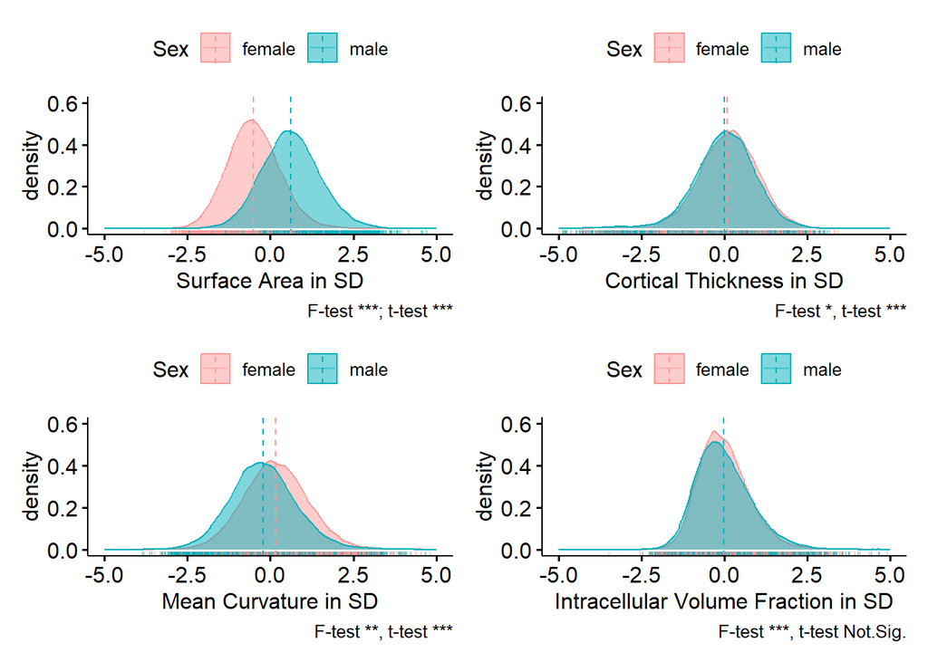

```r
par(mfrow = c(2, 2))
qqnorm(pgs.img$Struct_SA, pch = 1, frame = FALSE, ylim = c(-6, 8), main = "Q-Q Plot for Surface Area")
qqline(pgs.img$Struct_SA, col = "steelblue", lwd = 2)
qqnorm(pgs.img$Struct_CT, pch = 1, frame = FALSE, ylim = c(-6, 8), main = "Q-Q Plot for Cortical Thickness")
qqline(pgs.img$Struct_CT, col = "steelblue", lwd = 2)
qqnorm(pgs.img$Struct_meanCurv, pch = 1, frame = FALSE, ylim = c(-6, 8), main = "Q-Q Plot for Mean Curvature")
qqline(pgs.img$Struct_CT, col = "steelblue", lwd = 2)
qqnorm(pgs.img$meanNODDI_ICVF, pch = 1, frame = FALSE, ylim = c(-6, 8), main = "Q-Q Plot for Intracellular Volume Fraction")
qqline(pgs.img$Struct_CT, col = "steelblue", lwd = 2)
```

# Global Correlation Analysis

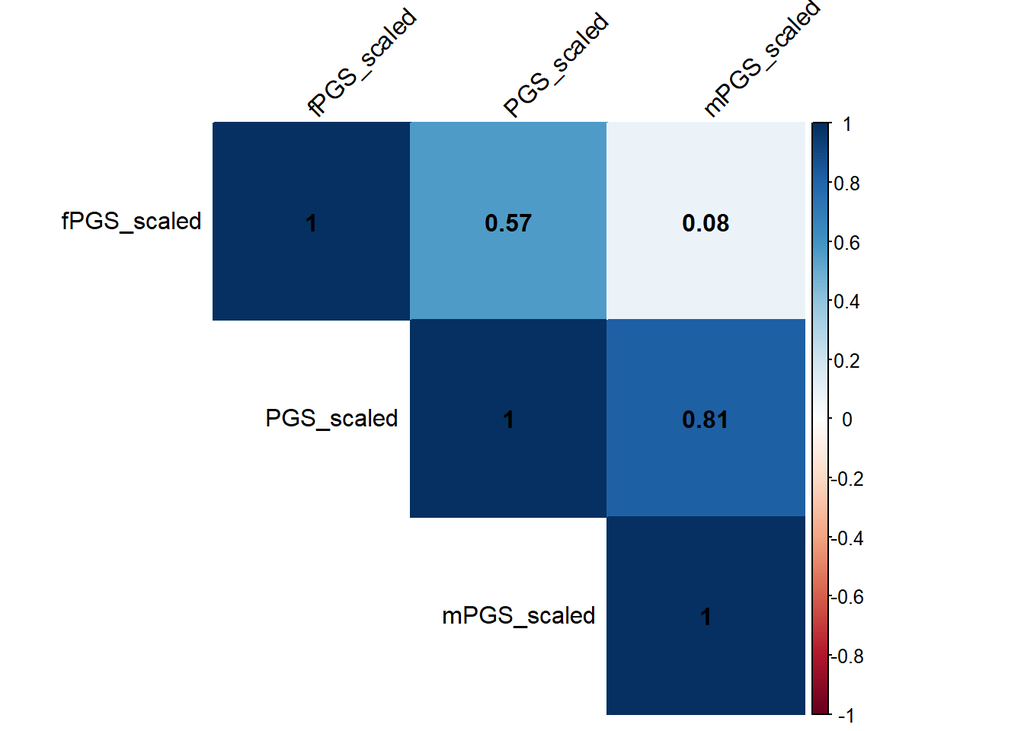

```r
# For between PGS
pgs.rcorr = rcorr(as.matrix(pgs.img[, c(55,57,59)])) # P = 0, what does it mean?
corrplot(pgs.rcorr$r, method = "color", type="upper", order="hclust", addCoef.col = "black", tl.col="black", tl.srt=45,
         p.mat = pgs.rcorr$P, sig.level = 0.05)
```

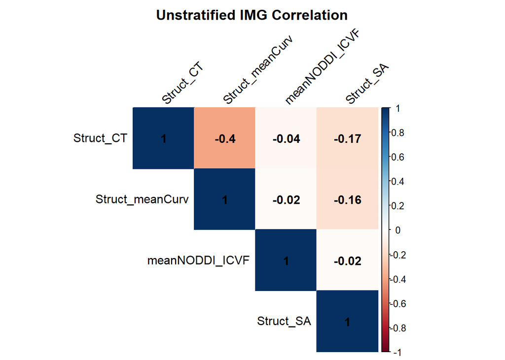

```r
# For IMG Phenotypes
img.rcorr <- rcorr(as.matrix(pgs.img[, c(60, 66, 69, 70)])) # For un-stratified population
f.img.rcorr <- rcorr(as.matrix(fpgs.img[, c(60, 66, 69, 70)])) # For female population
m.img.rcorr <- rcorr(as.matrix(mpgs.img[, c(60, 66, 69, 70)])) # For male population

# The output of corrplot produces a p-values matrix with zeroes on the diagonal.
# The output of rcorr produces a matrix of p-values with NA on the diagonal.
# This generates error message and stops corrplot from functioning.
# Fix suggested by stackoverflow is: Replace your NA diagonal values with zeroes.
# Source: https://stackoverflow.com/questions/70218485/corrplot-error-arguments-imply-differing-number-of-rows

img.rcorr$P[is.na(img.rcorr$P)] <- 0
f.img.rcorr$P[is.na(f.img.rcorr$P)] <- 0
m.img.rcorr$P[is.na(m.img.rcorr$P)] <- 0

corrplot(img.rcorr$r, method="color", type="upper", order="hclust", title = "Unstratified IMG Correlation",
         addCoef.col = "black", tl.col="black", tl.srt=45, p.mat = f.img.rcorr$P, sig.level = 0.05, mar=c(0,0,2,0))
```

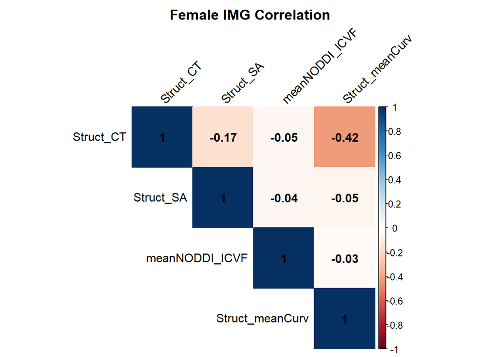

```r
corrplot(f.img.rcorr$r, method="color", type="upper", order="hclust", title = "Female IMG Correlation",
         addCoef.col = "black", tl.col="black", tl.srt=45, p.mat = f.img.rcorr$P, sig.level = 0.05, mar=c(0,0,2,0))
```

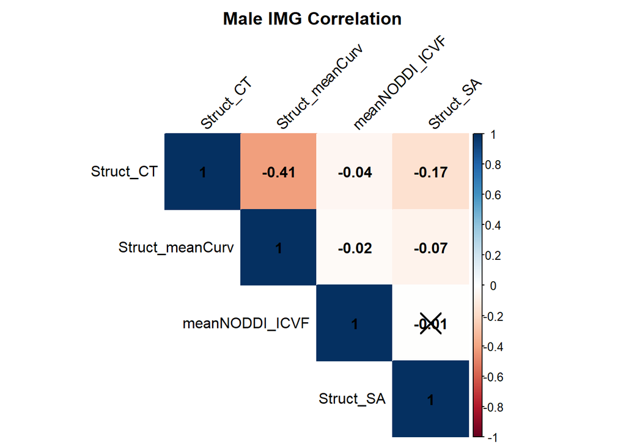

```r
corrplot(m.img.rcorr$r, method="color", type="upper", order="hclust", title = "Male IMG Correlation",
         addCoef.col = "black", tl.col="black", tl.srt=45, p.mat = m.img.rcorr$P, sig.level = 0.05, mar=c(0,0,2,0))
```

```r
# Graph improvement idea for reordering: rstatix::corr_reorder()
```

# Study of Global phenotype effect through Linear fixed effect models and summary

```r
# Using PGS_scaled value + sex + age + age^2 + age*sex + + age^2*sex + PC1...PC10 + scanning site + Euler Index + Frame wise displacement + batchId + T1T2 (only for struct_*)
# Total sum is skipped from now on as lm results are similar and generates same diagnosis graph in comparison to scaled_PGS

PGS.Str_SA <- lm(Struct_SA ~ PGS_scaled + Sex + Age + Agesquared + Sex * Age + Sex * Agesquared + X22009.0.1 + X22009.0.2 + X22009.0.3 + X22009.0.4 + X22009.0.5 +
                           X22009.0.6 + X22009.0.7 + X22009.0.8 + X22009.0.9 + X22009.0.10 + Scan.Site + eulerleftplusright + fd + T1T2 + batchID, data = pgs.img)

PGS.Str_CT <- lm(Struct_CT ~ PGS_scaled + Sex + Age + Agesquared + Sex * Age + Sex * Agesquared + X22009.0.1 + X22009.0.2 + X22009.0.3 + X22009.0.4 + X22009.0.5 +
                           X22009.0.6 + X22009.0.7 + X22009.0.8 + X22009.0.9 + X22009.0.10 + Scan.Site + eulerleftplusright + fd + T1T2 + batchID, data = pgs.img)

PGS.Str_MC <- lm(Struct_meanCurv ~ PGS_scaled + Sex + Age + Agesquared + Sex * Age + Sex * Agesquared + X22009.0.1 + X22009.0.2 + X22009.0.3 + X22009.0.4 +
                           X22009.0.5 + X22009.0.6 + X22009.0.7 + X22009.0.8 + X22009.0.9 + X22009.0.10 + Scan.Site + eulerleftplusright + fd + T1T2 + batchID,
                         data = pgs.img)

PGS.ICVF <- lm(meanNODDI_ICVF ~ PGS_scaled + Sex + Age + Agesquared + Sex * Age + Sex * Agesquared + X22009.0.1 + X22009.0.2 + X22009.0.3 + X22009.0.4 +
                           X22009.0.5 + X22009.0.6 + X22009.0.7 + X22009.0.8 + X22009.0.9 + X22009.0.10 + Scan.Site + eulerleftplusright + fd + batchID, data = pgs.img)

summary(PGS.Str_SA)
```

```
##
## Call:
## lm(formula = Struct_SA ~ PGS_scaled + Sex + Age + Agesquared +
##     Sex * Age + Sex * Agesquared + X22009.0.1 + X22009.0.2 +
##     X22009.0.3 + X22009.0.4 + X22009.0.5 + X22009.0.6 + X22009.0.7 +
##     X22009.0.8 + X22009.0.9 + X22009.0.10 + Scan.Site + eulerleftplusright +
##     fd + T1T2 + batchID, data = pgs.img)
##
## Residuals:
##     Min      1Q  Median      3Q     Max
## -3.3171 -0.5433 -0.0220  0.5208  4.0811
##
## Coefficients:
##                     Estimate Std. Error t value Pr(>|t|)
## (Intercept)         0.020608   0.004521   4.559 5.17e-06 ***
## PGS_scaled         -0.011954   0.004508  -2.652  0.00801 **
## Sex                 0.575543   0.004566 126.058  < 2e-16 ***
## Age                 0.176237   0.071883   2.452  0.01422 *
## Agesquared         -0.332657   0.072082  -4.615 3.95e-06 ***
## X22009.0.1         -0.014267   0.006754  -2.112  0.03467 *
## X22009.0.2         -0.004703   0.005420  -0.868  0.38554
## X22009.0.3         -0.012102   0.007020  -1.724  0.08474 .
## X22009.0.4         -0.001715   0.008285  -0.207  0.83600
## X22009.0.5          0.042110   0.005262   8.003 1.26e-15 ***
## X22009.0.6          0.008062   0.006331   1.273  0.20292
## X22009.0.7         -0.006829   0.005135  -1.330  0.18356
## X22009.0.8         -0.009755   0.006575  -1.484  0.13790
## X22009.0.9         -0.003517   0.004612  -0.763  0.44565
## X22009.0.10         0.008143   0.005269   1.545  0.12226
## Scan.Site          -0.036162   0.004770  -7.582 3.51e-14 ***
## eulerleftplusright  0.093057   0.004921  18.910  < 2e-16 ***
## fd                 -0.067356   0.004793 -14.054  < 2e-16 ***
## T1T2                0.009560   0.004511   2.119  0.03407 *
## batchID             0.006505   0.004504   1.444  0.14867
## Sex:Age            -0.104387   0.071179  -1.467  0.14251
## Sex:Agesquared      0.089219   0.071183   1.253  0.21008
## ---
## Signif. codes:  0 '***' 0.001 '**' 0.01 '*' 0.05 '.' 0.1 ' ' 1
##
## Residual standard error: 0.802 on 31757 degrees of freedom
##   (18 observations deleted due to missingness)
## Multiple R-squared:  0.3524, Adjusted R-squared:  0.352
## F-statistic:   823 on 21 and 31757 DF,  p-value: < 2.2e-16
```

```r
summary(PGS.Str_CT)
```

```
##
## Call:
## lm(formula = Struct_CT ~ PGS_scaled + Sex + Age + Agesquared +
##     Sex * Age + Sex * Agesquared + X22009.0.1 + X22009.0.2 +
##     X22009.0.3 + X22009.0.4 + X22009.0.5 + X22009.0.6 + X22009.0.7 +
##     X22009.0.8 + X22009.0.9 + X22009.0.10 + Scan.Site + eulerleftplusright +
##     fd + T1T2 + batchID, data = pgs.img)
##
## Residuals:
##     Min      1Q  Median      3Q     Max
## -3.5697 -0.5411  0.0029  0.5387  3.4286
##
## Coefficients:
##                     Estimate Std. Error t value Pr(>|t|)
## (Intercept)         0.054951   0.004566  12.035  < 2e-16 ***
## PGS_scaled          0.014212   0.004553   3.122 0.001801 **
## Sex                -0.012520   0.004611  -2.715 0.006632 **
## Age                -0.054123   0.072603  -0.745 0.455995
## Agesquared         -0.138001   0.072804  -1.896 0.058034 .
## X22009.0.1          0.009829   0.006822   1.441 0.149643
## X22009.0.2          0.006383   0.005474   1.166 0.243642
## X22009.0.3          0.005021   0.007090   0.708 0.478888
## X22009.0.4          0.008987   0.008368   1.074 0.282810
## X22009.0.5         -0.015468   0.005315  -2.910 0.003613 **
## X22009.0.6          0.002530   0.006395   0.396 0.692394
## X22009.0.7         -0.004116   0.005186  -0.794 0.427430
## X22009.0.8         -0.015876   0.006641  -2.391 0.016818 *
## X22009.0.9         -0.008355   0.004658  -1.794 0.072874 .
## X22009.0.10        -0.009754   0.005322  -1.833 0.066837 .
## Scan.Site          -0.034078   0.004817  -7.074 1.54e-12 ***
## eulerleftplusright -0.104700   0.004970 -21.065  < 2e-16 ***
## fd                 -0.018477   0.004841  -3.817 0.000135 ***
## T1T2                0.358413   0.004561  78.575  < 2e-16 ***
## batchID            -0.002341   0.004549  -0.515 0.606860
## Sex:Age             0.308433   0.071892   4.290 1.79e-05 ***
## Sex:Agesquared     -0.299375   0.071896  -4.164 3.14e-05 ***
## ---
## Signif. codes:  0 '***' 0.001 '**' 0.01 '*' 0.05 '.' 0.1 ' ' 1
##
## Residual standard error: 0.8101 on 31757 degrees of freedom
##   (18 observations deleted due to missingness)
## Multiple R-squared:  0.2269, Adjusted R-squared:  0.2264
## F-statistic: 443.9 on 21 and 31757 DF,  p-value: < 2.2e-16
```

```r
summary(PGS.Str_MC)
```

```
##
## Call:
## lm(formula = Struct_meanCurv ~ PGS_scaled + Sex + Age + Agesquared +
##     Sex * Age + Sex * Agesquared + X22009.0.1 + X22009.0.2 +
##     X22009.0.3 + X22009.0.4 + X22009.0.5 + X22009.0.6 + X22009.0.7 +
##     X22009.0.8 + X22009.0.9 + X22009.0.10 + Scan.Site + eulerleftplusright +
##     fd + T1T2 + batchID, data = pgs.img)
##
## Residuals:
##     Min      1Q  Median      3Q     Max
## -3.9113 -0.5884  0.0017  0.5884  3.7600
##
## Coefficients:
##                      Estimate Std. Error t value Pr(>|t|)
## (Intercept)        -0.0151149  0.0049524  -3.052  0.00228 **
## PGS_scaled         -0.0029680  0.0049381  -0.601  0.54782
## Sex                -0.2392467  0.0050017 -47.833  < 2e-16 ***
## Age                 0.3379684  0.0787479   4.292 1.78e-05 ***
## Agesquared         -0.3686049  0.0789665  -4.668 3.06e-06 ***
## X22009.0.1          0.0019516  0.0073994   0.264  0.79197
## X22009.0.2         -0.0073859  0.0059373  -1.244  0.21352
## X22009.0.3         -0.0005939  0.0076904  -0.077  0.93844
## X22009.0.4         -0.0088006  0.0090757  -0.970  0.33221
## X22009.0.5         -0.0119571  0.0057645  -2.074  0.03806 *
## X22009.0.6         -0.0079876  0.0069358  -1.152  0.24947
## X22009.0.7          0.0062478  0.0056252   1.111  0.26672
## X22009.0.8          0.0036525  0.0072024   0.507  0.61207
## X22009.0.9         -0.0003349  0.0050521  -0.066  0.94715
## X22009.0.10         0.0011996  0.0057725   0.208  0.83537
## Scan.Site           0.0098849  0.0052251   1.892  0.05853 .
## eulerleftplusright  0.3896931  0.0053963  72.215  < 2e-16 ***
## fd                  0.0973131  0.0052507  18.533  < 2e-16 ***
## T1T2               -0.0094768  0.0049416  -1.918  0.05515 .
## batchID             0.0007400  0.0049337   0.150  0.88077
## Sex:Age             0.0593496  0.0779755   0.761  0.44658
## Sex:Agesquared     -0.0770547  0.0779798  -0.988  0.32309
## ---
## Signif. codes:  0 '***' 0.001 '**' 0.01 '*' 0.05 '.' 0.1 ' ' 1
##
## Residual standard error: 0.8786 on 31757 degrees of freedom
##   (18 observations deleted due to missingness)
## Multiple R-squared:  0.2136, Adjusted R-squared:  0.2131
## F-statistic: 410.8 on 21 and 31757 DF,  p-value: < 2.2e-16
```

```r
summary(PGS.ICVF)
```

```
##
## Call:
## lm(formula = meanNODDI_ICVF ~ PGS_scaled + Sex + Age + Agesquared +
##     Sex * Age + Sex * Agesquared + X22009.0.1 + X22009.0.2 +
##     X22009.0.3 + X22009.0.4 + X22009.0.5 + X22009.0.6 + X22009.0.7 +
##     X22009.0.8 + X22009.0.9 + X22009.0.10 + Scan.Site + eulerleftplusright +
##     fd + batchID, data = pgs.img)
##
## Residuals:
##     Min      1Q  Median      3Q     Max
## -3.1342 -0.5235 -0.0754  0.4494  4.9663
##
## Coefficients:
##                      Estimate Std. Error t value Pr(>|t|)
## (Intercept)        -0.0172701  0.0042898  -4.026 5.69e-05 ***
## PGS_scaled         -0.0097404  0.0042780  -2.277 0.022801 *
## Sex                -0.0186810  0.0043327  -4.312 1.63e-05 ***
## Age                 0.3347734  0.0682246   4.907 9.30e-07 ***
## Agesquared         -0.2472420  0.0684169  -3.614 0.000302 ***
## X22009.0.1         -0.0004171  0.0064080  -0.065 0.948102
## X22009.0.2         -0.0054395  0.0051421  -1.058 0.290141
## X22009.0.3          0.0009957  0.0066605   0.149 0.881160
## X22009.0.4          0.0049371  0.0078616   0.628 0.530011
## X22009.0.5          0.0070112  0.0049933   1.404 0.160294
## X22009.0.6          0.0014945  0.0060083   0.249 0.803564
## X22009.0.7          0.0002524  0.0048720   0.052 0.958679
## X22009.0.8          0.0050928  0.0062378   0.816 0.414250
## X22009.0.9         -0.0062395  0.0043756  -1.426 0.153882
## X22009.0.10        -0.0072446  0.0050002  -1.449 0.147386
## Scan.Site           0.1103089  0.0045181  24.415  < 2e-16 ***
## eulerleftplusright -0.0109254  0.0046734  -2.338 0.019404 *
## fd                  0.1041891  0.0045491  22.903  < 2e-16 ***
## batchID             0.0013402  0.0042727   0.314 0.753774
## Sex:Age            -0.0651667  0.0675545  -0.965 0.334726
## Sex:Agesquared      0.0644677  0.0675623   0.954 0.339991
## ---
## Signif. codes:  0 '***' 0.001 '**' 0.01 '*' 0.05 '.' 0.1 ' ' 1
##
## Residual standard error: 0.7609 on 31747 degrees of freedom
##   (29 observations deleted due to missingness)
## Multiple R-squared:  0.0596, Adjusted R-squared:  0.059
## F-statistic: 100.6 on 20 and 31747 DF,  p-value: < 2.2e-16
```

```r
PGS.sex.Str_SA <- lm(Struct_SA ~ PGS_scaled + Sex + Age + Agesquared + Sex * Age + Sex * Agesquared + PGS_scaled * Sex + X22009.0.1 + X22009.0.2 + X22009.0.3 + X22009.0.4 + X22009.0.5 +
                           X22009.0.6 + X22009.0.7 + X22009.0.8 + X22009.0.9 + X22009.0.10 + Scan.Site + eulerleftplusright + fd + T1T2 + batchID, data = pgs.img)

PGS.sex.Str_CT <- lm(Struct_CT ~ PGS_scaled + Sex + Age + Agesquared + Sex * Age + Sex * Agesquared + PGS_scaled * Sex + X22009.0.1 + X22009.0.2 + X22009.0.3 + X22009.0.4 + X22009.0.5 +
                           X22009.0.6 + X22009.0.7 + X22009.0.8 + X22009.0.9 + X22009.0.10 + Scan.Site + eulerleftplusright + fd + T1T2 + batchID, data = pgs.img)

PGS.sex.Str_MC <- lm(Struct_meanCurv ~ PGS_scaled + Sex + Age + Agesquared + Sex * Age + Sex * Agesquared + PGS_scaled * Sex + X22009.0.1 + X22009.0.2 + X22009.0.3 + X22009.0.4 +
                           X22009.0.5 + X22009.0.6 + X22009.0.7 + X22009.0.8 + X22009.0.9 + X22009.0.10 + Scan.Site + eulerleftplusright + fd + T1T2 + batchID,
                         data = pgs.img)

PGS.sex.ICVF <- lm(meanNODDI_ICVF ~ PGS_scaled + Sex + Age + Agesquared + Sex * Age + Sex * Agesquared + PGS_scaled * Sex + X22009.0.1 + X22009.0.2 + X22009.0.3 + X22009.0.4 +
                           X22009.0.5 + X22009.0.6 + X22009.0.7 + X22009.0.8 + X22009.0.9 + X22009.0.10 + Scan.Site + eulerleftplusright + fd + batchID, data = pgs.img)

summary(PGS.sex.Str_SA)
```

```
##
## Call:
## lm(formula = Struct_SA ~ PGS_scaled + Sex + Age + Agesquared +
##     Sex * Age + Sex * Agesquared + PGS_scaled * Sex + X22009.0.1 +
##     X22009.0.2 + X22009.0.3 + X22009.0.4 + X22009.0.5 + X22009.0.6 +
##     X22009.0.7 + X22009.0.8 + X22009.0.9 + X22009.0.10 + Scan.Site +
##     eulerleftplusright + fd + T1T2 + batchID, data = pgs.img)
##
## Residuals:
##     Min      1Q  Median      3Q     Max
## -3.3172 -0.5435 -0.0218  0.5205  4.0791
##
## Coefficients:
##                     Estimate Std. Error t value Pr(>|t|)
## (Intercept)         0.020587   0.004521   4.553 5.30e-06 ***
## PGS_scaled         -0.011954   0.004508  -2.652  0.00801 **
## Sex                 0.575541   0.004566 126.055  < 2e-16 ***
## Age                 0.176273   0.071884   2.452  0.01420 *
## Agesquared         -0.332695   0.072083  -4.615 3.94e-06 ***
## X22009.0.1         -0.014275   0.006754  -2.114  0.03456 *
## X22009.0.2         -0.004701   0.005420  -0.867  0.38576
## X22009.0.3         -0.012112   0.007020  -1.725  0.08449 .
## X22009.0.4         -0.001737   0.008285  -0.210  0.83395
## X22009.0.5          0.042102   0.005262   8.001 1.28e-15 ***
## X22009.0.6          0.008043   0.006332   1.270  0.20401
## X22009.0.7         -0.006811   0.005135  -1.326  0.18478
## X22009.0.8         -0.009732   0.006575  -1.480  0.13887
## X22009.0.9         -0.003514   0.004612  -0.762  0.44615
## X22009.0.10         0.008151   0.005269   1.547  0.12190
## Scan.Site          -0.036154   0.004770  -7.580 3.56e-14 ***
## eulerleftplusright  0.093046   0.004921  18.907  < 2e-16 ***
## fd                 -0.067351   0.004793 -14.052  < 2e-16 ***
## T1T2                0.009566   0.004511   2.121  0.03396 *
## batchID             0.006509   0.004504   1.445  0.14842
## Sex:Age            -0.104512   0.071182  -1.468  0.14205
## Sex:Agesquared      0.089332   0.071185   1.255  0.20952
## PGS_scaled:Sex     -0.001307   0.004502  -0.290  0.77156
## ---
## Signif. codes:  0 '***' 0.001 '**' 0.01 '*' 0.05 '.' 0.1 ' ' 1
##
## Residual standard error: 0.8021 on 31756 degrees of freedom
##   (18 observations deleted due to missingness)
## Multiple R-squared:  0.3524, Adjusted R-squared:  0.352
## F-statistic: 785.5 on 22 and 31756 DF,  p-value: < 2.2e-16
```

```r
summary(PGS.sex.Str_CT)
```

```
##
## Call:
## lm(formula = Struct_CT ~ PGS_scaled + Sex + Age + Agesquared +
##     Sex * Age + Sex * Agesquared + PGS_scaled * Sex + X22009.0.1 +
##     X22009.0.2 + X22009.0.3 + X22009.0.4 + X22009.0.5 + X22009.0.6 +
##     X22009.0.7 + X22009.0.8 + X22009.0.9 + X22009.0.10 + Scan.Site +
##     eulerleftplusright + fd + T1T2 + batchID, data = pgs.img)
##
## Residuals:
##     Min      1Q  Median      3Q     Max
## -3.5720 -0.5428  0.0021  0.5392  3.4279
##
## Coefficients:
##                     Estimate Std. Error t value Pr(>|t|)
## (Intercept)         0.054880   0.004567  12.018  < 2e-16 ***
## PGS_scaled          0.014210   0.004553   3.121 0.001804 **
## Sex                -0.012527   0.004611  -2.717 0.006601 **
## Age                -0.054002   0.072603  -0.744 0.457005
## Agesquared         -0.138131   0.072805  -1.897 0.057800 .
## X22009.0.1          0.009800   0.006822   1.436 0.150872
## X22009.0.2          0.006390   0.005474   1.167 0.243095
## X22009.0.3          0.004987   0.007091   0.703 0.481883
## X22009.0.4          0.008913   0.008368   1.065 0.286830
## X22009.0.5         -0.015495   0.005315  -2.915 0.003554 **
## X22009.0.6          0.002466   0.006395   0.386 0.699763
## X22009.0.7         -0.004054   0.005187  -0.782 0.434485
## X22009.0.8         -0.015798   0.006641  -2.379 0.017375 *
## X22009.0.9         -0.008342   0.004658  -1.791 0.073312 .
## X22009.0.10        -0.009726   0.005322  -1.828 0.067630 .
## Scan.Site          -0.034051   0.004817  -7.068 1.60e-12 ***
## eulerleftplusright -0.104736   0.004971 -21.071  < 2e-16 ***
## fd                 -0.018460   0.004841  -3.813 0.000137 ***
## T1T2                0.358433   0.004561  78.579  < 2e-16 ***
## batchID            -0.002327   0.004549  -0.511 0.609010
## Sex:Age             0.308004   0.071894   4.284 1.84e-05 ***
## Sex:Agesquared     -0.298990   0.071898  -4.159 3.21e-05 ***
## PGS_scaled:Sex     -0.004428   0.004547  -0.974 0.330153
## ---
## Signif. codes:  0 '***' 0.001 '**' 0.01 '*' 0.05 '.' 0.1 ' ' 1
##
## Residual standard error: 0.8101 on 31756 degrees of freedom
##   (18 observations deleted due to missingness)
## Multiple R-squared:  0.227,  Adjusted R-squared:  0.2264
## F-statistic: 423.8 on 22 and 31756 DF,  p-value: < 2.2e-16
```

```r
summary(PGS.sex.Str_MC)
```

```
##
## Call:
## lm(formula = Struct_meanCurv ~ PGS_scaled + Sex + Age + Agesquared +
##     Sex * Age + Sex * Agesquared + PGS_scaled * Sex + X22009.0.1 +
##     X22009.0.2 + X22009.0.3 + X22009.0.4 + X22009.0.5 + X22009.0.6 +
##     X22009.0.7 + X22009.0.8 + X22009.0.9 + X22009.0.10 + Scan.Site +
##     eulerleftplusright + fd + T1T2 + batchID, data = pgs.img)
##
## Residuals:
##     Min      1Q  Median      3Q     Max
## -3.9096 -0.5883  0.0022  0.5891  3.7595
##
## Coefficients:
##                      Estimate Std. Error t value Pr(>|t|)
## (Intercept)        -0.0152265  0.0049530  -3.074  0.00211 **
## PGS_scaled         -0.0029708  0.0049381  -0.602  0.54743
## Sex                -0.2392584  0.0050017 -47.836  < 2e-16 ***
## Age                 0.3381631  0.0787468   4.294 1.76e-05 ***
## Agesquared         -0.3688134  0.0789654  -4.671 3.02e-06 ***
## X22009.0.1          0.0019053  0.0073993   0.258  0.79679
## X22009.0.2         -0.0073744  0.0059372  -1.242  0.21422
## X22009.0.3         -0.0006474  0.0076904  -0.084  0.93291
## X22009.0.4         -0.0089168  0.0090760  -0.982  0.32588
## X22009.0.5         -0.0119998  0.0057644  -2.082  0.03738 *
## X22009.0.6         -0.0080874  0.0069360  -1.166  0.24362
## X22009.0.7          0.0063449  0.0056256   1.128  0.25938
## X22009.0.8          0.0037750  0.0072029   0.524  0.60022
## X22009.0.9         -0.0003151  0.0050521  -0.062  0.95027
## X22009.0.10         0.0012430  0.0057725   0.215  0.82952
## Scan.Site           0.0099270  0.0052251   1.900  0.05746 .
## eulerleftplusright  0.3896398  0.0053964  72.204  < 2e-16 ***
## fd                  0.0973401  0.0052506  18.539  < 2e-16 ***
## T1T2               -0.0094442  0.0049416  -1.911  0.05599 .
## batchID             0.0007618  0.0049337   0.154  0.87729
## Sex:Age             0.0586819  0.0779758   0.753  0.45172
## Sex:Agesquared     -0.0764563  0.0779797  -0.980  0.32686
## PGS_scaled:Sex     -0.0069174  0.0049316  -1.403  0.16072
## ---
## Signif. codes:  0 '***' 0.001 '**' 0.01 '*' 0.05 '.' 0.1 ' ' 1
##
## Residual standard error: 0.8786 on 31756 degrees of freedom
##   (18 observations deleted due to missingness)
## Multiple R-squared:  0.2136, Adjusted R-squared:  0.2131
## F-statistic: 392.2 on 22 and 31756 DF,  p-value: < 2.2e-16
```

```r
summary(PGS.sex.ICVF)
```

```
##
## Call:
## lm(formula = meanNODDI_ICVF ~ PGS_scaled + Sex + Age + Agesquared +
##     Sex * Age + Sex * Agesquared + PGS_scaled * Sex + X22009.0.1 +
##     X22009.0.2 + X22009.0.3 + X22009.0.4 + X22009.0.5 + X22009.0.6 +
##     X22009.0.7 + X22009.0.8 + X22009.0.9 + X22009.0.10 + Scan.Site +
##     eulerleftplusright + fd + batchID, data = pgs.img)
##
## Residuals:
##     Min      1Q  Median      3Q     Max
## -3.1320 -0.5241 -0.0755  0.4496  4.9613
##
## Coefficients:
##                      Estimate Std. Error t value Pr(>|t|)
## (Intercept)        -0.0172082  0.0042904  -4.011 6.06e-05 ***
## PGS_scaled         -0.0097379  0.0042780  -2.276 0.022836 *
## Sex                -0.0186754  0.0043327  -4.310 1.64e-05 ***
## Age                 0.3346601  0.0682250   4.905 9.38e-07 ***
## Agesquared         -0.2471211  0.0684173  -3.612 0.000304 ***
## X22009.0.1         -0.0003943  0.0064081  -0.062 0.950939
## X22009.0.2         -0.0054462  0.0051421  -1.059 0.289545
## X22009.0.3          0.0010251  0.0066606   0.154 0.877691
## X22009.0.4          0.0049982  0.0078620   0.636 0.524951
## X22009.0.5          0.0070350  0.0049934   1.409 0.158883
## X22009.0.6          0.0015486  0.0060086   0.258 0.796618
## X22009.0.7          0.0001974  0.0048724   0.041 0.967682
## X22009.0.8          0.0050247  0.0062383   0.805 0.420562
## X22009.0.9         -0.0062507  0.0043756  -1.429 0.153152
## X22009.0.10        -0.0072686  0.0050003  -1.454 0.146057
## Scan.Site           0.1102851  0.0045182  24.409  < 2e-16 ***
## eulerleftplusright -0.0108942  0.0046735  -2.331 0.019758 *
## fd                  0.1041731  0.0045492  22.899  < 2e-16 ***
## batchID             0.0013277  0.0042727   0.311 0.756004
## Sex:Age            -0.0647966  0.0675560  -0.959 0.337488
## Sex:Agesquared      0.0641363  0.0675635   0.949 0.342489
## PGS_scaled:Sex      0.0038111  0.0042724   0.892 0.372382
## ---
## Signif. codes:  0 '***' 0.001 '**' 0.01 '*' 0.05 '.' 0.1 ' ' 1
##
## Residual standard error: 0.7609 on 31746 degrees of freedom
##   (29 observations deleted due to missingness)
## Multiple R-squared:  0.05962,    Adjusted R-squared:  0.059
## F-statistic: 95.84 on 21 and 31746 DF,  p-value: < 2.2e-16
```

```r
# For SA
export_summs(PGS.Str_SA, PGS.sex.Str_SA,
             model.names = c("SA~PGS", "SA~PGS + Sex Interaction"),
             coefs = c("(Intercept)", "Sex", "Age", "Age^2" = "Agesquared", "Sex:Age", "Sex:Age^2" = "Sex:Agesquared",
                       "PGS_scaled", "PGS:Sex" = "PGS_scaled:Sex"))
```

|  | SA~PGS | SA~PGS + Sex Interaction |
| --- | --- | --- |
| (Intercept) | 0.02 *** | 0.02 *** |
|  | (0.00) | (0.00) |
| Sex | 0.58 *** | 0.58 *** |
|  | (0.00) | (0.00) |
| Age | 0.18 * | 0.18 * |
|  | (0.07) | (0.07) |
| Age^2 | -0.33 *** | -0.33 *** |
|  | (0.07) | (0.07) |
| Sex:Age | -0.10 | -0.10 |
|  | (0.07) | (0.07) |
| Sex:Age^2 | 0.09 | 0.09 |
|  | (0.07) | (0.07) |
| PGS_scaled | -0.01 ** | -0.01 ** |
|  | (0.00) | (0.00) |
| PGS:Sex |  | -0.00 |
|  |  | (0.00) |
| N | 31779 | 31779 |
| R2 | 0.35 | 0.35 |
| *** p < 0.001; ** p < 0.01; * p < 0.05. |  |  |

```r
# For CT
export_summs(PGS.Str_CT, PGS.sex.Str_CT,
             model.names = c("CT~PGS", "CT~PGS + Sex Interaction"),
             coefs = c("(Intercept)", "Sex", "Age", "Age^2" = "Agesquared", "Sex:Age", "Sex:Age^2" = "Sex:Agesquared",
                       "PGS_scaled", "PGS:Sex" = "PGS_scaled:Sex"))
```

|  | CT~PGS | CT~PGS + Sex Interaction |
| --- | --- | --- |
| (Intercept) | 0.05 *** | 0.05 *** |
|  | (0.00) | (0.00) |
| Sex | -0.01 ** | -0.01 ** |
|  | (0.00) | (0.00) |
| Age | -0.05 | -0.05 |
|  | (0.07) | (0.07) |
| Age^2 | -0.14 | -0.14 |
|  | (0.07) | (0.07) |
| Sex:Age | 0.31 *** | 0.31 *** |
|  | (0.07) | (0.07) |
| Sex:Age^2 | -0.30 *** | -0.30 *** |
|  | (0.07) | (0.07) |
| PGS_scaled | 0.01 ** | 0.01 ** |
|  | (0.00) | (0.00) |
| PGS:Sex |  | -0.00 |
|  |  | (0.00) |
| N | 31779 | 31779 |
| R2 | 0.23 | 0.23 |
| *** p < 0.001; ** p < 0.01; * p < 0.05. |  |  |

```r
# For MC
export_summs(PGS.Str_MC, PGS.sex.Str_MC,
             model.names = c("MC~PGS", "MC~PGS + Sex Interaction"),
             coefs = c("(Intercept)", "Sex", "Age", "Age^2" = "Agesquared", "Sex:Age", "Sex:Age^2" = "Sex:Agesquared",
                       "PGS_scaled", "PGS:Sex" = "PGS_scaled:Sex"))
```

|  | MC~PGS | MC~PGS + Sex Interaction |
| --- | --- | --- |
| (Intercept) | -0.02 ** | -0.02 ** |
|  | (0.00) | (0.00) |
| Sex | -0.24 *** | -0.24 *** |
|  | (0.01) | (0.01) |
| Age | 0.34 *** | 0.34 *** |
|  | (0.08) | (0.08) |
| Age^2 | -0.37 *** | -0.37 *** |
|  | (0.08) | (0.08) |
| Sex:Age | 0.06 | 0.06 |
|  | (0.08) | (0.08) |
| Sex:Age^2 | -0.08 | -0.08 |
|  | (0.08) | (0.08) |
| PGS_scaled | -0.00 | -0.00 |
|  | (0.00) | (0.00) |
| PGS:Sex |  | -0.01 |
|  |  | (0.00) |
| N | 31779 | 31779 |
| R2 | 0.21 | 0.21 |
| *** p < 0.001; ** p < 0.01; * p < 0.05. |  |  |

```r
# For ICVF
export_summs(PGS.ICVF, PGS.sex.ICVF,
             model.names = c("ICVF~PGS", "ICVF~PGS + Sex Interaction"),
             coefs = c("(Intercept)", "Sex", "Age", "Age^2" = "Agesquared", "Sex:Age", "Sex:Age^2" = "Sex:Agesquared",
                       "PGS_scaled", "PGS:Sex" = "PGS_scaled:Sex"))
```

|  | ICVF~PGS | ICVF~PGS + Sex Interaction |
| --- | --- | --- |
| (Intercept) | -0.02 *** | -0.02 *** |
|  | (0.00) | (0.00) |
| Sex | -0.02 *** | -0.02 *** |
|  | (0.00) | (0.00) |
| Age | 0.33 *** | 0.33 *** |
|  | (0.07) | (0.07) |
| Age^2 | -0.25 *** | -0.25 *** |
|  | (0.07) | (0.07) |
| Sex:Age | -0.07 | -0.06 |
|  | (0.07) | (0.07) |
| Sex:Age^2 | 0.06 | 0.06 |
|  | (0.07) | (0.07) |
| PGS_scaled | -0.01 * | -0.01 * |
|  | (0.00) | (0.00) |
| PGS:Sex |  | 0.00 |
|  |  | (0.00) |
| N | 31768 | 31768 |
| R2 | 0.06 | 0.06 |
| *** p < 0.001; ** p < 0.01; * p < 0.05. |  |  |

## Conclusion: For global phenotype, sex, age, age^2 and sometimes PGS are important factors that affects towards brain structure, but not PGS:Sex interaction effect.

# Study of Sex Difference between male and female population through Linear fixed effect models and summary

```r
# For female
fPGS.Str_SA <- lm(Struct_SA ~ fPGS_scaled + Age + Agesquared + X22009.0.1 + X22009.0.2 + X22009.0.3 + X22009.0.4 + X22009.0.5 +
                           X22009.0.6 + X22009.0.7 + X22009.0.8 + X22009.0.9 + X22009.0.10 + Scan.Site + eulerleftplusright + fd + T1T2 + batchID, data = fpgs.img)

fPGS.Str_CT <- lm(Struct_CT ~ fPGS_scaled + Age + Agesquared + X22009.0.1 + X22009.0.2 + X22009.0.3 + X22009.0.4 + X22009.0.5 +
                           X22009.0.6 + X22009.0.7 + X22009.0.8 + X22009.0.9 + X22009.0.10 + Scan.Site + eulerleftplusright + fd + T1T2 + batchID, data = fpgs.img)

fPGS.Str_MC <- lm(Struct_meanCurv ~ fPGS_scaled + Age + Agesquared + X22009.0.1 + X22009.0.2 + X22009.0.3 + X22009.0.4 +
                           X22009.0.5 + X22009.0.6 + X22009.0.7 + X22009.0.8 + X22009.0.9 + X22009.0.10 + Scan.Site + eulerleftplusright + fd + T1T2 + batchID, data = fpgs.img)

fPGS.ICVF <- lm(meanNODDI_ICVF ~ fPGS_scaled + Age + Agesquared + X22009.0.1 + X22009.0.2 + X22009.0.3 + X22009.0.4 +
                           X22009.0.5 + X22009.0.6 + X22009.0.7 + X22009.0.8 + X22009.0.9 + X22009.0.10 + Scan.Site + eulerleftplusright + fd + batchID, data = fpgs.img)

summary(fPGS.Str_SA)
```

```
##
## Call:
## lm(formula = Struct_SA ~ fPGS_scaled + Age + Agesquared + X22009.0.1 +
##     X22009.0.2 + X22009.0.3 + X22009.0.4 + X22009.0.5 + X22009.0.6 +
##     X22009.0.7 + X22009.0.8 + X22009.0.9 + X22009.0.10 + Scan.Site +
##     eulerleftplusright + fd + T1T2 + batchID, data = fpgs.img)
##
## Residuals:
##     Min      1Q  Median      3Q     Max
## -4.2231 -0.6642 -0.0305  0.6336  4.0220
##
## Coefficients:
##                      Estimate Std. Error t value Pr(>|t|)
## (Intercept)         2.609e-06  7.520e-03   0.000  0.99972
## fPGS_scaled        -1.802e-02  7.533e-03  -2.392  0.01678 *
## Age                 3.838e-01  1.199e-01   3.202  0.00137 **
## Agesquared         -5.653e-01  1.202e-01  -4.705 2.56e-06 ***
## X22009.0.1         -1.880e-02  1.125e-02  -1.671  0.09465 .
## X22009.0.2         -7.252e-03  9.135e-03  -0.794  0.42728
## X22009.0.3         -2.221e-02  1.157e-02  -1.919  0.05498 .
## X22009.0.4         -1.243e-02  1.381e-02  -0.900  0.36808
## X22009.0.5          6.148e-02  8.778e-03   7.004 2.59e-12 ***
## X22009.0.6          9.435e-03  1.107e-02   0.852  0.39395
## X22009.0.7         -1.702e-02  8.908e-03  -1.911  0.05605 .
## X22009.0.8         -9.708e-03  1.148e-02  -0.846  0.39768
## X22009.0.9         -3.330e-03  7.727e-03  -0.431  0.66646
## X22009.0.10         8.651e-03  8.919e-03   0.970  0.33207
## Scan.Site          -4.325e-02  8.016e-03  -5.396 6.91e-08 ***
## eulerleftplusright  1.190e-01  8.068e-03  14.748  < 2e-16 ***
## fd                 -7.234e-02  7.904e-03  -9.153  < 2e-16 ***
## T1T2                1.737e-02  7.542e-03   2.304  0.02124 *
## batchID             4.141e-03  7.531e-03   0.550  0.58241
## ---
## Signif. codes:  0 '***' 0.001 '**' 0.01 '*' 0.05 '.' 0.1 ' ' 1
##
## Residual standard error: 0.9754 on 16802 degrees of freedom
##   (12 observations deleted due to missingness)
## Multiple R-squared:  0.0497, Adjusted R-squared:  0.04868
## F-statistic: 48.82 on 18 and 16802 DF,  p-value: < 2.2e-16
```

```r
summary(fPGS.Str_CT)
```

```
##
## Call:
## lm(formula = Struct_CT ~ fPGS_scaled + Age + Agesquared + X22009.0.1 +
##     X22009.0.2 + X22009.0.3 + X22009.0.4 + X22009.0.5 + X22009.0.6 +
##     X22009.0.7 + X22009.0.8 + X22009.0.9 + X22009.0.10 + Scan.Site +
##     eulerleftplusright + fd + T1T2 + batchID, data = fpgs.img)
##
## Residuals:
##     Min      1Q  Median      3Q     Max
## -3.8273 -0.5990  0.0147  0.5931  3.3691
##
## Coefficients:
##                      Estimate Std. Error t value Pr(>|t|)
## (Intercept)         9.355e-05  6.835e-03   0.014 0.989080
## fPGS_scaled         1.449e-02  6.846e-03   2.116 0.034324 *
## Age                -4.045e-01  1.090e-01  -3.712 0.000206 ***
## Agesquared          1.885e-01  1.092e-01   1.726 0.084345 .
## X22009.0.1          1.068e-02  1.022e-02   1.045 0.296147
## X22009.0.2          3.687e-03  8.302e-03   0.444 0.656950
## X22009.0.3          4.135e-03  1.052e-02   0.393 0.694179
## X22009.0.4          1.126e-02  1.255e-02   0.897 0.369728
## X22009.0.5         -1.925e-02  7.979e-03  -2.413 0.015842 *
## X22009.0.6         -6.404e-04  1.006e-02  -0.064 0.949241
## X22009.0.7         -9.843e-03  8.097e-03  -1.216 0.224147
## X22009.0.8         -1.948e-02  1.043e-02  -1.867 0.061867 .
## X22009.0.9         -1.319e-02  7.023e-03  -1.879 0.060329 .
## X22009.0.10        -7.941e-03  8.106e-03  -0.980 0.327257
## Scan.Site          -3.614e-02  7.286e-03  -4.960 7.11e-07 ***
## eulerleftplusright -1.149e-01  7.333e-03 -15.666  < 2e-16 ***
## fd                  2.030e-03  7.184e-03   0.283 0.777502
## T1T2                3.795e-01  6.855e-03  55.363  < 2e-16 ***
## batchID            -7.098e-03  6.845e-03  -1.037 0.299757
## ---
## Signif. codes:  0 '***' 0.001 '**' 0.01 '*' 0.05 '.' 0.1 ' ' 1
##
## Residual standard error: 0.8865 on 16803 degrees of freedom
##   (11 observations deleted due to missingness)
## Multiple R-squared:  0.2149, Adjusted R-squared:  0.2141
## F-statistic: 255.6 on 18 and 16803 DF,  p-value: < 2.2e-16
```

```r
summary(fPGS.Str_MC)
```

```
##
## Call:
## lm(formula = Struct_meanCurv ~ fPGS_scaled + Age + Agesquared +
##     X22009.0.1 + X22009.0.2 + X22009.0.3 + X22009.0.4 + X22009.0.5 +
##     X22009.0.6 + X22009.0.7 + X22009.0.8 + X22009.0.9 + X22009.0.10 +
##     Scan.Site + eulerleftplusright + fd + T1T2 + batchID, data = fpgs.img)
##
## Residuals:
##     Min      1Q  Median      3Q     Max
## -4.1026 -0.6169 -0.0022  0.6168  3.8712
##
## Coefficients:
##                      Estimate Std. Error t value Pr(>|t|)
## (Intercept)         9.792e-05  7.117e-03   0.014  0.98902
## fPGS_scaled        -9.037e-03  7.128e-03  -1.268  0.20490
## Age                 3.127e-01  1.135e-01   2.756  0.00586 **
## Agesquared         -3.287e-01  1.137e-01  -2.890  0.00385 **
## X22009.0.1         -9.772e-03  1.065e-02  -0.918  0.35865
## X22009.0.2         -3.020e-03  8.644e-03  -0.349  0.72682
## X22009.0.3          1.581e-03  1.095e-02   0.144  0.88518
## X22009.0.4         -1.502e-02  1.307e-02  -1.149  0.25048
## X22009.0.5         -1.115e-02  8.307e-03  -1.342  0.17950
## X22009.0.6          2.916e-03  1.047e-02   0.278  0.78072
## X22009.0.7          5.570e-03  8.430e-03   0.661  0.50884
## X22009.0.8         -2.463e-04  1.086e-02  -0.023  0.98191
## X22009.0.9         -1.654e-03  7.312e-03  -0.226  0.82102
## X22009.0.10         9.204e-03  8.440e-03   1.090  0.27554
## Scan.Site           9.442e-03  7.586e-03   1.245  0.21328
## eulerleftplusright  3.583e-01  7.654e-03  46.808  < 2e-16 ***
## fd                  9.068e-02  7.480e-03  12.122  < 2e-16 ***
## T1T2               -5.342e-03  7.137e-03  -0.748  0.45419
## batchID             1.911e-03  7.127e-03   0.268  0.78857
## ---
## Signif. codes:  0 '***' 0.001 '**' 0.01 '*' 0.05 '.' 0.1 ' ' 1
##
## Residual standard error: 0.923 on 16802 degrees of freedom
##   (12 observations deleted due to missingness)
## Multiple R-squared:  0.1489, Adjusted R-squared:  0.148
## F-statistic: 163.4 on 18 and 16802 DF,  p-value: < 2.2e-16
```

```r
summary(fPGS.ICVF)
```

```
##
## Call:
## lm(formula = meanNODDI_ICVF ~ fPGS_scaled + Age + Agesquared +
##     X22009.0.1 + X22009.0.2 + X22009.0.3 + X22009.0.4 + X22009.0.5 +
##     X22009.0.6 + X22009.0.7 + X22009.0.8 + X22009.0.9 + X22009.0.10 +
##     Scan.Site + eulerleftplusright + fd + batchID, data = fpgs.img)
##
## Residuals:
##     Min      1Q  Median      3Q     Max
## -4.1298 -0.6492 -0.0858  0.5688  6.6289
##
## Coefficients:
##                      Estimate Std. Error t value Pr(>|t|)
## (Intercept)         0.0002190  0.0073855   0.030 0.976342
## fPGS_scaled        -0.0001862  0.0073958  -0.025 0.979911
## Age                 0.5554872  0.1177830   4.716 2.42e-06 ***
## Agesquared         -0.4515847  0.1180588  -3.825 0.000131 ***
## X22009.0.1          0.0078180  0.0110429   0.708 0.478978
## X22009.0.2         -0.0168731  0.0089688  -1.881 0.059947 .
## X22009.0.3          0.0037261  0.0113614   0.328 0.742944
## X22009.0.4          0.0171539  0.0135534   1.266 0.205654
## X22009.0.5          0.0111587  0.0086169   1.295 0.195346
## X22009.0.6          0.0132547  0.0108711   1.219 0.222761
## X22009.0.7          0.0047247  0.0087420   0.540 0.588884
## X22009.0.8          0.0040898  0.0112690   0.363 0.716667
## X22009.0.9         -0.0032013  0.0075864  -0.422 0.673051
## X22009.0.10        -0.0091711  0.0087574  -1.047 0.295004
## Scan.Site           0.1639274  0.0078598  20.856  < 2e-16 ***
## eulerleftplusright  0.0041708  0.0079371   0.525 0.599254
## fd                  0.1648787  0.0077632  21.239  < 2e-16 ***
## batchID             0.0081106  0.0073928   1.097 0.272618
## ---
## Signif. codes:  0 '***' 0.001 '**' 0.01 '*' 0.05 '.' 0.1 ' ' 1
##
## Residual standard error: 0.9578 on 16800 degrees of freedom
##   (15 observations deleted due to missingness)
## Multiple R-squared:  0.08359,    Adjusted R-squared:  0.08266
## F-statistic: 90.14 on 17 and 16800 DF,  p-value: < 2.2e-16
```

```r
# For Male
mPGS.Str_SA <- lm(Struct_SA ~ mPGS_scaled + Age + Agesquared + X22009.0.1 + X22009.0.2 + X22009.0.3 + X22009.0.4 + X22009.0.5 + X22009.0.6 + X22009.0.7 + X22009.0.8 + X22009.0.9 + X22009.0.10
                  + Scan.Site + eulerleftplusright + fd + T1T2 + batchID, data = mpgs.img)

mPGS.Str_CT <- lm(Struct_CT ~ mPGS_scaled + Age + Agesquared + X22009.0.1 + X22009.0.2 + X22009.0.3 + X22009.0.4 + X22009.0.5 +
                           X22009.0.6 + X22009.0.7 + X22009.0.8 + X22009.0.9 + X22009.0.10 + Scan.Site + eulerleftplusright + fd + T1T2 + batchID, data = mpgs.img)

mPGS.Str_MC <- lm(Struct_meanCurv ~ mPGS_scaled + Age + Agesquared + X22009.0.1 + X22009.0.2 + X22009.0.3 + X22009.0.4 +
                           X22009.0.5 + X22009.0.6 + X22009.0.7 + X22009.0.8 + X22009.0.9 + X22009.0.10 + Scan.Site + eulerleftplusright + fd + T1T2 + batchID, data = mpgs.img)

mPGS.ICVF <- lm(meanNODDI_ICVF ~ mPGS_scaled + Age + Agesquared + X22009.0.1 + X22009.0.2 + X22009.0.3 + X22009.0.4 +
                           X22009.0.5 + X22009.0.6 + X22009.0.7 + X22009.0.8 + X22009.0.9 + X22009.0.10 + Scan.Site + eulerleftplusright + fd + batchID, data = mpgs.img)
summary(mPGS.Str_SA)
```

```
##
## Call:
## lm(formula = Struct_SA ~ mPGS_scaled + Age + Agesquared + X22009.0.1 +
##     X22009.0.2 + X22009.0.3 + X22009.0.4 + X22009.0.5 + X22009.0.6 +
##     X22009.0.7 + X22009.0.8 + X22009.0.9 + X22009.0.10 + Scan.Site +
##     eulerleftplusright + fd + T1T2 + batchID, data = mpgs.img)
##
## Residuals:
##     Min      1Q  Median      3Q     Max
## -3.2214 -0.6576 -0.0241  0.6332  4.7202
##
## Coefficients:
##                      Estimate Std. Error t value Pr(>|t|)
## (Intercept)        -4.145e-05  7.967e-03  -0.005   0.9958
## mPGS_scaled        -8.008e-03  7.983e-03  -1.003   0.3158
## Age                 5.639e-02  1.267e-01   0.445   0.6562
## Agesquared         -2.552e-01  1.269e-01  -2.010   0.0444 *
## X22009.0.1         -1.653e-02  1.204e-02  -1.374   0.1695
## X22009.0.2         -3.761e-03  9.521e-03  -0.395   0.6928
## X22009.0.3         -5.956e-03  1.265e-02  -0.471   0.6379
## X22009.0.4          9.524e-03  1.474e-02   0.646   0.5182
## X22009.0.5          4.117e-02  9.351e-03   4.403 1.07e-05 ***
## X22009.0.6          9.208e-03  1.061e-02   0.868   0.3855
## X22009.0.7          1.985e-03  8.718e-03   0.228   0.8199
## X22009.0.8         -1.540e-02  1.105e-02  -1.393   0.1635
## X22009.0.9         -5.394e-03  8.151e-03  -0.662   0.5081
## X22009.0.10         1.085e-02  9.209e-03   1.179   0.2386
## Scan.Site          -4.540e-02  8.401e-03  -5.404 6.60e-08 ***
## eulerleftplusright  1.082e-01  8.772e-03  12.339  < 2e-16 ***
## fd                 -8.792e-02  8.447e-03 -10.408  < 2e-16 ***
## T1T2                5.875e-03  7.993e-03   0.735   0.4624
## batchID             1.156e-02  7.977e-03   1.449   0.1474
## ---
## Signif. codes:  0 '***' 0.001 '**' 0.01 '*' 0.05 '.' 0.1 ' ' 1
##
## Residual standard error: 0.9744 on 14939 degrees of freedom
##   (6 observations deleted due to missingness)
## Multiple R-squared:  0.0516, Adjusted R-squared:  0.05045
## F-statistic: 45.15 on 18 and 14939 DF,  p-value: < 2.2e-16
```

```r
summary(mPGS.Str_CT)
```

```
##
## Call:
## lm(formula = Struct_CT ~ mPGS_scaled + Age + Agesquared + X22009.0.1 +
##     X22009.0.2 + X22009.0.3 + X22009.0.4 + X22009.0.5 + X22009.0.6 +
##     X22009.0.7 + X22009.0.8 + X22009.0.9 + X22009.0.10 + Scan.Site +
##     eulerleftplusright + fd + T1T2 + batchID, data = mpgs.img)
##
## Residuals:
##     Min      1Q  Median      3Q     Max
## -3.4532 -0.5786 -0.0063  0.5745  3.7084
##
## Coefficients:
##                      Estimate Std. Error t value Pr(>|t|)
## (Intercept)        -0.0002469  0.0071448  -0.035  0.97243
## mPGS_scaled         0.0067808  0.0071587   0.947  0.34354
## Age                 0.3322937  0.1135802   2.926  0.00344 **
## Agesquared         -0.5366157  0.1138324  -4.714 2.45e-06 ***
## X22009.0.1          0.0108008  0.0107924   1.001  0.31695
## X22009.0.2          0.0109929  0.0085373   1.288  0.19790
## X22009.0.3          0.0065888  0.0113477   0.581  0.56150
## X22009.0.4          0.0074004  0.0132171   0.560  0.57554
## X22009.0.5         -0.0139365  0.0083848  -1.662  0.09651 .
## X22009.0.6          0.0064974  0.0095143   0.683  0.49467
## X22009.0.7          0.0008495  0.0078180   0.109  0.91347
## X22009.0.8         -0.0145028  0.0099112  -1.463  0.14341
## X22009.0.9         -0.0041305  0.0073093  -0.565  0.57201
## X22009.0.10        -0.0138945  0.0082579  -1.683  0.09248 .
## Scan.Site          -0.0376548  0.0075336  -4.998 5.85e-07 ***
## eulerleftplusright -0.1111620  0.0078660 -14.132  < 2e-16 ***
## fd                 -0.0413332  0.0075753  -5.456 4.94e-08 ***
## T1T2                0.4006188  0.0071845  55.762  < 2e-16 ***
## batchID             0.0030891  0.0071528   0.432  0.66584
## ---
## Signif. codes:  0 '***' 0.001 '**' 0.01 '*' 0.05 '.' 0.1 ' ' 1
##
## Residual standard error: 0.8738 on 14938 degrees of freedom
##   (7 observations deleted due to missingness)
## Multiple R-squared:  0.2374, Adjusted R-squared:  0.2365
## F-statistic: 258.3 on 18 and 14938 DF,  p-value: < 2.2e-16
```

```r
summary(mPGS.Str_MC)
```

```
##
## Call:
## lm(formula = Struct_meanCurv ~ mPGS_scaled + Age + Agesquared +
##     X22009.0.1 + X22009.0.2 + X22009.0.3 + X22009.0.4 + X22009.0.5 +
##     X22009.0.6 + X22009.0.7 + X22009.0.8 + X22009.0.9 + X22009.0.10 +
##     Scan.Site + eulerleftplusright + fd + T1T2 + batchID, data = mpgs.img)
##
## Residuals:
##     Min      1Q  Median      3Q     Max
## -3.7474 -0.5899  0.0036  0.5941  3.8214
##
## Coefficients:
##                      Estimate Std. Error t value Pr(>|t|)
## (Intercept)        -1.458e-05  7.216e-03  -0.002 0.998388
## mPGS_scaled        -2.106e-04  7.230e-03  -0.029 0.976758
## Age                 3.932e-01  1.147e-01   3.428 0.000611 ***
## Agesquared         -4.434e-01  1.150e-01  -3.857 0.000116 ***
## X22009.0.1          1.492e-02  1.090e-02   1.369 0.171038
## X22009.0.2         -1.360e-02  8.622e-03  -1.577 0.114775
## X22009.0.3         -4.255e-03  1.146e-02  -0.371 0.710407
## X22009.0.4         -2.836e-03  1.335e-02  -0.212 0.831732
## X22009.0.5         -1.359e-02  8.468e-03  -1.605 0.108440
## X22009.0.6         -1.869e-02  9.609e-03  -1.946 0.051725 .
## X22009.0.7          7.592e-03  7.896e-03   0.962 0.336313
## X22009.0.8          6.030e-03  1.001e-02   0.602 0.546873
## X22009.0.9          9.200e-04  7.382e-03   0.125 0.900819
## X22009.0.10        -7.982e-03  8.340e-03  -0.957 0.338552
## Scan.Site           1.062e-02  7.608e-03   1.396 0.162722
## eulerleftplusright  4.377e-01  7.944e-03  55.096  < 2e-16 ***
## fd                  1.081e-01  7.650e-03  14.129  < 2e-16 ***
## T1T2               -1.454e-02  7.239e-03  -2.009 0.044592 *
## batchID            -5.387e-04  7.224e-03  -0.075 0.940560
## ---
## Signif. codes:  0 '***' 0.001 '**' 0.01 '*' 0.05 '.' 0.1 ' ' 1
##
## Residual standard error: 0.8825 on 14939 degrees of freedom
##   (6 observations deleted due to missingness)
## Multiple R-squared:  0.2221, Adjusted R-squared:  0.2212
## F-statistic:   237 on 18 and 14939 DF,  p-value: < 2.2e-16
```

```r
summary(mPGS.ICVF)
```

```
##
## Call:
## lm(formula = meanNODDI_ICVF ~ mPGS_scaled + Age + Agesquared +
##     X22009.0.1 + X22009.0.2 + X22009.0.3 + X22009.0.4 + X22009.0.5 +
##     X22009.0.6 + X22009.0.7 + X22009.0.8 + X22009.0.9 + X22009.0.10 +
##     Scan.Site + eulerleftplusright + fd + batchID, data = mpgs.img)
##
## Residuals:
##     Min      1Q  Median      3Q     Max
## -3.0886 -0.6842 -0.1083  0.5824  5.8592
##
## Coefficients:
##                      Estimate Std. Error t value Pr(>|t|)
## (Intercept)         0.0001481  0.0080112   0.018  0.98525
## mPGS_scaled        -0.0064600  0.0080261  -0.805  0.42091
## Age                 0.3138106  0.1273284   2.465  0.01373 *
## Agesquared         -0.2008164  0.1276129  -1.574  0.11559
## X22009.0.1         -0.0109406  0.0120996  -0.904  0.36590
## X22009.0.2          0.0042552  0.0095726   0.445  0.65667
## X22009.0.3         -0.0002612  0.0127229  -0.021  0.98362
## X22009.0.4         -0.0048081  0.0148327  -0.324  0.74582
## X22009.0.5          0.0055824  0.0094078   0.593  0.55294
## X22009.0.6         -0.0093355  0.0106671  -0.875  0.38150
## X22009.0.7         -0.0004636  0.0087725  -0.053  0.95786
## X22009.0.8          0.0086359  0.0111144   0.777  0.43717
## X22009.0.9         -0.0123991  0.0081948  -1.513  0.13029
## X22009.0.10        -0.0105359  0.0092614  -1.138  0.25530
## Scan.Site           0.1153337  0.0084319  13.678  < 2e-16 ***
## eulerleftplusright -0.0247031  0.0088210  -2.800  0.00511 **
## fd                  0.1047852  0.0084974  12.332  < 2e-16 ***
## batchID            -0.0046721  0.0080191  -0.583  0.56016
## ---
## Signif. codes:  0 '***' 0.001 '**' 0.01 '*' 0.05 '.' 0.1 ' ' 1
##
## Residual standard error: 0.9795 on 14932 degrees of freedom
##   (14 observations deleted due to missingness)
## Multiple R-squared:  0.04162,    Adjusted R-squared:  0.04053
## F-statistic: 38.14 on 17 and 14932 DF,  p-value: < 2.2e-16
```

```r
# For SA
export_summs(PGS.Str_SA, PGS.sex.Str_SA, fPGS.Str_SA, mPGS.Str_SA,
             model.names = c("SA~PGS", "SA~PGS + Sex Interaction", "fSA~fPGS", "mSA~mPGS"),
             coefs = c("(Intercept)", "Sex", "Age", "Age^2" = "Agesquared", "Sex:Age", "Sex:Age^2" = "Sex:Agesquared",
                       "PGS_scaled", "fPGS_scaled", "mPGS_scaled", "PGS:Sex" = "PGS_scaled:Sex"))
```

|  | SA~PGS | SA~PGS + Sex Interaction | fSA~fPGS | mSA~mPGS |
| --- | --- | --- | --- | --- |
| (Intercept) | 0.02 *** | 0.02 *** | 0.00 | -0.00 |
|  | (0.00) | (0.00) | (0.01) | (0.01) |
| Sex | 0.58 *** | 0.58 *** |  |  |
|  | (0.00) | (0.00) |  |  |
| Age | 0.18 * | 0.18 * | 0.38 ** | 0.06 |
|  | (0.07) | (0.07) | (0.12) | (0.13) |
| Age^2 | -0.33 *** | -0.33 *** | -0.57 *** | -0.26 * |
|  | (0.07) | (0.07) | (0.12) | (0.13) |
| Sex:Age | -0.10 | -0.10 |  |  |
|  | (0.07) | (0.07) |  |  |
| Sex:Age^2 | 0.09 | 0.09 |  |  |
|  | (0.07) | (0.07) |  |  |
| PGS_scaled | -0.01 ** | -0.01 ** |  |  |
|  | (0.00) | (0.00) |  |  |
| fPGS_scaled |  |  | -0.02 * |  |
|  |  |  | (0.01) |  |
| mPGS_scaled |  |  |  | -0.01 |
|  |  |  |  | (0.01) |
| PGS:Sex |  | -0.00 |  |  |
|  |  | (0.00) |  |  |
| N | 31779 | 31779 | 16821 | 14958 |
| R2 | 0.35 | 0.35 | 0.05 | 0.05 |
| *** p < 0.001; ** p < 0.01; * p < 0.05. |  |  |  |  |

```r
# For CT
export_summs(PGS.Str_CT, PGS.sex.Str_CT, fPGS.Str_CT, mPGS.Str_CT,
             model.names = c("CT~PGS", "CT~PGS + Sex Interaction", "fCT~fPGS", "mCT~mPGS"),
             coefs = c("(Intercept)", "Sex", "Age", "Age^2" = "Agesquared", "Sex:Age", "Sex:Age^2" = "Sex:Agesquared",
                       "PGS_scaled", "fPGS_scaled", "mPGS_scaled", "PGS:Sex" = "PGS_scaled:Sex"))
```

|  | CT~PGS | CT~PGS + Sex Interaction | fCT~fPGS | mCT~mPGS |
| --- | --- | --- | --- | --- |
| (Intercept) | 0.05 *** | 0.05 *** | 0.00 | -0.00 |
|  | (0.00) | (0.00) | (0.01) | (0.01) |
| Sex | -0.01 ** | -0.01 ** |  |  |
|  | (0.00) | (0.00) |  |  |
| Age | -0.05 | -0.05 | -0.40 *** | 0.33 ** |
|  | (0.07) | (0.07) | (0.11) | (0.11) |
| Age^2 | -0.14 | -0.14 | 0.19 | -0.54 *** |
|  | (0.07) | (0.07) | (0.11) | (0.11) |
| Sex:Age | 0.31 *** | 0.31 *** |  |  |
|  | (0.07) | (0.07) |  |  |
| Sex:Age^2 | -0.30 *** | -0.30 *** |  |  |
|  | (0.07) | (0.07) |  |  |
| PGS_scaled | 0.01 ** | 0.01 ** |  |  |
|  | (0.00) | (0.00) |  |  |
| fPGS_scaled |  |  | 0.01 * |  |
|  |  |  | (0.01) |  |
| mPGS_scaled |  |  |  | 0.01 |
|  |  |  |  | (0.01) |
| PGS:Sex |  | -0.00 |  |  |
|  |  | (0.00) |  |  |
| N | 31779 | 31779 | 16822 | 14957 |
| R2 | 0.23 | 0.23 | 0.21 | 0.24 |
| *** p < 0.001; ** p < 0.01; * p < 0.05. |  |  |  |  |

```r
# For MC
export_summs(PGS.Str_MC, PGS.sex.Str_MC,  fPGS.Str_MC, mPGS.Str_MC,
             model.names = c("MC~PGS", "MC~PGS + Sex Interaction", "fMC~fPGS", "mMC~mPGS"),
             coefs = c("(Intercept)", "Sex", "Age", "Age^2" = "Agesquared", "Sex:Age", "Sex:Age^2" = "Sex:Agesquared",
                       "PGS_scaled", "fPGS_scaled", "mPGS_scaled", "PGS:Sex" = "PGS_scaled:Sex"))
```

|  | MC~PGS | MC~PGS + Sex Interaction | fMC~fPGS | mMC~mPGS |
| --- | --- | --- | --- | --- |
| (Intercept) | -0.02 ** | -0.02 ** | 0.00 | -0.00 |
|  | (0.00) | (0.00) | (0.01) | (0.01) |
| Sex | -0.24 *** | -0.24 *** |  |  |
|  | (0.01) | (0.01) |  |  |
| Age | 0.34 *** | 0.34 *** | 0.31 ** | 0.39 *** |
|  | (0.08) | (0.08) | (0.11) | (0.11) |
| Age^2 | -0.37 *** | -0.37 *** | -0.33 ** | -0.44 *** |
|  | (0.08) | (0.08) | (0.11) | (0.11) |
| Sex:Age | 0.06 | 0.06 |  |  |
|  | (0.08) | (0.08) |  |  |
| Sex:Age^2 | -0.08 | -0.08 |  |  |
|  | (0.08) | (0.08) |  |  |
| PGS_scaled | -0.00 | -0.00 |  |  |
|  | (0.00) | (0.00) |  |  |
| fPGS_scaled |  |  | -0.01 |  |
|  |  |  | (0.01) |  |
| mPGS_scaled |  |  |  | -0.00 |
|  |  |  |  | (0.01) |
| PGS:Sex |  | -0.01 |  |  |
|  |  | (0.00) |  |  |
| N | 31779 | 31779 | 16821 | 14958 |
| R2 | 0.21 | 0.21 | 0.15 | 0.22 |
| *** p < 0.001; ** p < 0.01; * p < 0.05. |  |  |  |  |

```r
# For ICVF
export_summs(PGS.ICVF, PGS.sex.ICVF,  fPGS.ICVF, mPGS.ICVF,
             model.names = c("ICVF~PGS", "ICVF~PGS + Sex Interaction", "fICVF~fPGS", "mICVF~mPGS"),
             coefs = c("(Intercept)", "Sex", "Age", "Age^2" = "Agesquared", "Sex:Age", "Sex:Age^2" = "Sex:Agesquared",
                       "PGS_scaled", "fPGS_scaled", "mPGS_scaled", "PGS:Sex" = "PGS_scaled:Sex"))
```

|  | ICVF~PGS | ICVF~PGS + Sex Interaction | fICVF~fPGS | mICVF~mPGS |
| --- | --- | --- | --- | --- |
| (Intercept) | -0.02 *** | -0.02 *** | 0.00 | 0.00 |
|  | (0.00) | (0.00) | (0.01) | (0.01) |
| Sex | -0.02 *** | -0.02 *** |  |  |
|  | (0.00) | (0.00) |  |  |
| Age | 0.33 *** | 0.33 *** | 0.56 *** | 0.31 * |
|  | (0.07) | (0.07) | (0.12) | (0.13) |
| Age^2 | -0.25 *** | -0.25 *** | -0.45 *** | -0.20 |
|  | (0.07) | (0.07) | (0.12) | (0.13) |
| Sex:Age | -0.07 | -0.06 |  |  |
|  | (0.07) | (0.07) |  |  |
| Sex:Age^2 | 0.06 | 0.06 |  |  |
|  | (0.07) | (0.07) |  |  |
| PGS_scaled | -0.01 * | -0.01 * |  |  |
|  | (0.00) | (0.00) |  |  |
| fPGS_scaled |  |  | -0.00 |  |
|  |  |  | (0.01) |  |
| mPGS_scaled |  |  |  | -0.01 |
|  |  |  |  | (0.01) |
| PGS:Sex |  | 0.00 |  |  |
|  |  | (0.00) |  |  |
| N | 31768 | 31768 | 16818 | 14950 |
| R2 | 0.06 | 0.06 | 0.08 | 0.04 |
| *** p < 0.001; ** p < 0.01; * p < 0.05. |  |  |  |  |

## Conclusion: For global phenotype, fPGS in female population is significantly associate with Surface Area and Cortical thickness, but otherwise no observed effect of sex difference from mPGS in male population.

## Thought: Maybe we should check on the original code used for generating fPGS and mPGS, as fPGS seem to have much more effect in the direction predicted than mPGS, despite power.

# Data Visualisation of PGS, fPGS in female, mPGS in male and PGS:SEX effect using summary result plot, Inc.R2 plot and prediction effect plot

```r
# For Unstratified Population
Str_SA <- lm(Struct_SA ~ Sex + Age + Agesquared + Sex * Age + Sex * Agesquared + X22009.0.1 + X22009.0.2 + X22009.0.3 + X22009.0.4 + X22009.0.5 +
                           X22009.0.6 + X22009.0.7 + X22009.0.8 + X22009.0.9 + X22009.0.10 + Scan.Site + eulerleftplusright + fd + T1T2 + batchID, data = pgs.img)

Str_CT <- lm(Struct_CT ~ Sex + Age + Agesquared + Sex * Age + Sex * Agesquared + X22009.0.1 + X22009.0.2 + X22009.0.3 + X22009.0.4 + X22009.0.5 +
                           X22009.0.6 + X22009.0.7 + X22009.0.8 + X22009.0.9 + X22009.0.10 + Scan.Site + eulerleftplusright + fd + T1T2 + batchID, data = pgs.img)

Str_MC <- lm(Struct_meanCurv ~ Sex + Age + Agesquared + Sex * Age + Sex * Agesquared + X22009.0.1 + X22009.0.2 + X22009.0.3 + X22009.0.4 +
                           X22009.0.5 + X22009.0.6 + X22009.0.7 + X22009.0.8 + X22009.0.9 + X22009.0.10 + Scan.Site + eulerleftplusright + fd + T1T2 + batchID,
                         data = pgs.img)

ICVF <- lm(meanNODDI_ICVF ~ Sex + Age + Agesquared + Sex * Age + Sex * Agesquared + X22009.0.1 + X22009.0.2 + X22009.0.3 + X22009.0.4 +
                           X22009.0.5 + X22009.0.6 + X22009.0.7 + X22009.0.8 + X22009.0.9 + X22009.0.10 + Scan.Site + eulerleftplusright + fd + batchID, data = pgs.img)

# For female population
fStr_SA <- lm(Struct_SA ~ Age + Agesquared + X22009.0.1 + X22009.0.2 + X22009.0.3 + X22009.0.4 + X22009.0.5 +
                           X22009.0.6 + X22009.0.7 + X22009.0.8 + X22009.0.9 + X22009.0.10 + Scan.Site + eulerleftplusright + fd + T1T2 + batchID, data = fpgs.img)

fStr_CT <- lm(Struct_CT ~ Age + Agesquared + X22009.0.1 + X22009.0.2 + X22009.0.3 + X22009.0.4 + X22009.0.5 +
                           X22009.0.6 + X22009.0.7 + X22009.0.8 + X22009.0.9 + X22009.0.10 + Scan.Site + eulerleftplusright + fd + T1T2 + batchID, data = fpgs.img)

fStr_MC <- lm(Struct_meanCurv ~ Age + Agesquared + X22009.0.1 + X22009.0.2 + X22009.0.3 + X22009.0.4 +
                           X22009.0.5 + X22009.0.6 + X22009.0.7 + X22009.0.8 + X22009.0.9 + X22009.0.10 + Scan.Site + eulerleftplusright + fd + T1T2 + batchID,
                         data = fpgs.img)

fICVF <- lm(meanNODDI_ICVF ~ Age + Agesquared + X22009.0.1 + X22009.0.2 + X22009.0.3 + X22009.0.4 +
                           X22009.0.5 + X22009.0.6 + X22009.0.7 + X22009.0.8 + X22009.0.9 + X22009.0.10 + Scan.Site + eulerleftplusright + fd + batchID, data = fpgs.img)

# For male population
mStr_SA <- lm(Struct_SA ~ Age + Agesquared + X22009.0.1 + X22009.0.2 + X22009.0.3 + X22009.0.4 + X22009.0.5 +
                           X22009.0.6 + X22009.0.7 + X22009.0.8 + X22009.0.9 + X22009.0.10 + Scan.Site + eulerleftplusright + fd + T1T2 + batchID, data = mpgs.img)

mStr_CT <- lm(Struct_CT ~ Age + Agesquared + X22009.0.1 + X22009.0.2 + X22009.0.3 + X22009.0.4 + X22009.0.5 +
                           X22009.0.6 + X22009.0.7 + X22009.0.8 + X22009.0.9 + X22009.0.10 + Scan.Site + eulerleftplusright + fd + T1T2 + batchID, data = mpgs.img)

mStr_MC <- lm(Struct_meanCurv ~ Age + Agesquared + X22009.0.1 + X22009.0.2 + X22009.0.3 + X22009.0.4 +
                           X22009.0.5 + X22009.0.6 + X22009.0.7 + X22009.0.8 + X22009.0.9 + X22009.0.10 + Scan.Site + eulerleftplusright + fd + T1T2 + batchID,
                         data = mpgs.img)

mICVF <- lm(meanNODDI_ICVF ~ Age + Agesquared + X22009.0.1 + X22009.0.2 + X22009.0.3 + X22009.0.4 +
                           X22009.0.5 + X22009.0.6 + X22009.0.7 + X22009.0.8 + X22009.0.9 + X22009.0.10 + Scan.Site + eulerleftplusright + fd + batchID, data = mpgs.img)
```

```r
# For SA
export_summs(PGS.Str_SA, PGS.sex.Str_SA, fPGS.Str_SA, mPGS.Str_SA, Str_SA, fStr_SA, mStr_SA,
             model.names = c("SA~PGS", "SA~PGS + Sex Interaction", "fSA~fPGS", "mSA~mPGS", "SA~Covar", "fSA~Covar", "mSA~Covar"),
             coefs = c("(Intercept)", "Sex", "Age", "Age^2" = "Agesquared", "Sex:Age", "Sex:Age^2" = "Sex:Agesquared",
                       "PGS_scaled", "fPGS_scaled", "mPGS_scaled", "PGS:Sex" = "PGS_scaled:Sex"))
```

|  | SA~PGS | SA~PGS + Sex Interaction | fSA~fPGS | mSA~mPGS | SA~Covar | fSA~Covar | mSA~Covar |
| --- | --- | --- | --- | --- | --- | --- | --- |
| (Intercept) | 0.02 *** | 0.02 *** | 0.00 | -0.00 | 0.02 *** | 0.00 | -0.00 |
|  | (0.00) | (0.00) | (0.01) | (0.01) | (0.00) | (0.01) | (0.01) |
| Sex | 0.58 *** | 0.58 *** |  |  | 0.58 *** |  |  |
|  | (0.00) | (0.00) |  |  | (0.00) |  |  |
| Age | 0.18 * | 0.18 * | 0.38 ** | 0.06 | 0.18 * | 0.39 ** | 0.06 |
|  | (0.07) | (0.07) | (0.12) | (0.13) | (0.07) | (0.12) | (0.13) |
| Age^2 | -0.33 *** | -0.33 *** | -0.57 *** | -0.26 * | -0.33 *** | -0.57 *** | -0.26 * |
|  | (0.07) | (0.07) | (0.12) | (0.13) | (0.07) | (0.12) | (0.13) |
| Sex:Age | -0.10 | -0.10 |  |  | -0.10 |  |  |
|  | (0.07) | (0.07) |  |  | (0.07) |  |  |
| Sex:Age^2 | 0.09 | 0.09 |  |  | 0.09 |  |  |
|  | (0.07) | (0.07) |  |  | (0.07) |  |  |
| PGS_scaled | -0.01 ** | -0.01 ** |  |  |  |  |  |
|  | (0.00) | (0.00) |  |  |  |  |  |
| fPGS_scaled |  |  | -0.02 * |  |  |  |  |
|  |  |  | (0.01) |  |  |  |  |
| mPGS_scaled |  |  |  | -0.01 |  |  |  |
|  |  |  |  | (0.01) |  |  |  |
| PGS:Sex |  | -0.00 |  |  |  |  |  |
|  |  | (0.00) |  |  |  |  |  |
| N | 31779 | 31779 | 16821 | 14958 | 31779 | 16821 | 14958 |
| R2 | 0.35 | 0.35 | 0.05 | 0.05 | 0.35 | 0.05 | 0.05 |
| *** p < 0.001; ** p < 0.01; * p < 0.05. |  |  |  |  |  |  |  |

```r
# For CT
export_summs(PGS.Str_CT, PGS.sex.Str_CT, fPGS.Str_CT, mPGS.Str_CT, Str_CT, fStr_CT, mStr_CT,
             model.names = c("CT~PGS", "CT~PGS + Sex Interaction", "fCT~fPGS", "mCT~mPGS", "CT~Covar", "fCT~Covar", "mCT~Covar"),
             coefs = c("(Intercept)", "Sex", "Age", "Age^2" = "Agesquared", "Sex:Age", "Sex:Age^2" = "Sex:Agesquared",
                       "PGS_scaled", "fPGS_scaled", "mPGS_scaled", "PGS:Sex" = "PGS_scaled:Sex"))
```

|  | CT~PGS | CT~PGS + Sex Interaction | fCT~fPGS | mCT~mPGS | CT~Covar | fCT~Covar | mCT~Covar |
| --- | --- | --- | --- | --- | --- | --- | --- |
| (Intercept) | 0.05 *** | 0.05 *** | 0.00 | -0.00 | 0.05 *** | 0.00 | -0.00 |
|  | (0.00) | (0.00) | (0.01) | (0.01) | (0.00) | (0.01) | (0.01) |
| Sex | -0.01 ** | -0.01 ** |  |  | -0.01 ** |  |  |
|  | (0.00) | (0.00) |  |  | (0.00) |  |  |
| Age | -0.05 | -0.05 | -0.40 *** | 0.33 ** | -0.06 | -0.41 *** | 0.33 ** |
|  | (0.07) | (0.07) | (0.11) | (0.11) | (0.07) | (0.11) | (0.11) |
| Age^2 | -0.14 | -0.14 | 0.19 | -0.54 *** | -0.14 | 0.19 | -0.54 *** |
|  | (0.07) | (0.07) | (0.11) | (0.11) | (0.07) | (0.11) | (0.11) |
| Sex:Age | 0.31 *** | 0.31 *** |  |  | 0.31 *** |  |  |
|  | (0.07) | (0.07) |  |  | (0.07) |  |  |
| Sex:Age^2 | -0.30 *** | -0.30 *** |  |  | -0.30 *** |  |  |
|  | (0.07) | (0.07) |  |  | (0.07) |  |  |
| PGS_scaled | 0.01 ** | 0.01 ** |  |  |  |  |  |
|  | (0.00) | (0.00) |  |  |  |  |  |
| fPGS_scaled |  |  | 0.01 * |  |  |  |  |
|  |  |  | (0.01) |  |  |  |  |
| mPGS_scaled |  |  |  | 0.01 |  |  |  |
|  |  |  |  | (0.01) |  |  |  |
| PGS:Sex |  | -0.00 |  |  |  |  |  |
|  |  | (0.00) |  |  |  |  |  |
| N | 31779 | 31779 | 16822 | 14957 | 31779 | 16822 | 14957 |
| R2 | 0.23 | 0.23 | 0.21 | 0.24 | 0.23 | 0.21 | 0.24 |
| *** p < 0.001; ** p < 0.01; * p < 0.05. |  |  |  |  |  |  |  |

```r
# For MC
export_summs(PGS.Str_MC, PGS.sex.Str_MC, fPGS.Str_MC, mPGS.Str_MC, Str_MC, fStr_MC, mStr_MC,
             model.names = c("MC~PGS", "MC~PGS + Sex Interaction", "fMC~fPGS", "mMC~mPGS", "MC~Covar", "fMC~Covar", "mMC~Covar"),
             coefs = c("(Intercept)", "Sex", "Age", "Age^2" = "Agesquared", "Sex:Age", "Sex:Age^2" = "Sex:Agesquared",
                       "PGS_scaled", "fPGS_scaled", "mPGS_scaled", "PGS:Sex" = "PGS_scaled:Sex"))
```

|  | MC~PGS | MC~PGS + Sex Interaction | fMC~fPGS | mMC~mPGS | MC~Covar | fMC~Covar | mMC~Covar |
| --- | --- | --- | --- | --- | --- | --- | --- |
| (Intercept) | -0.02 ** | -0.02 ** | 0.00 | -0.00 | -0.02 ** | 0.00 | -0.00 |
|  | (0.00) | (0.00) | (0.01) | (0.01) | (0.00) | (0.01) | (0.01) |
| Sex | -0.24 *** | -0.24 *** |  |  | -0.24 *** |  |  |
|  | (0.01) | (0.01) |  |  | (0.01) |  |  |
| Age | 0.34 *** | 0.34 *** | 0.31 ** | 0.39 *** | 0.34 *** | 0.31 ** | 0.39 *** |
|  | (0.08) | (0.08) | (0.11) | (0.11) | (0.08) | (0.11) | (0.11) |
| Age^2 | -0.37 *** | -0.37 *** | -0.33 ** | -0.44 *** | -0.37 *** | -0.33 ** | -0.44 *** |
|  | (0.08) | (0.08) | (0.11) | (0.11) | (0.08) | (0.11) | (0.11) |
| Sex:Age | 0.06 | 0.06 |  |  | 0.06 |  |  |
|  | (0.08) | (0.08) |  |  | (0.08) |  |  |
| Sex:Age^2 | -0.08 | -0.08 |  |  | -0.08 |  |  |
|  | (0.08) | (0.08) |  |  | (0.08) |  |  |
| PGS_scaled | -0.00 | -0.00 |  |  |  |  |  |
|  | (0.00) | (0.00) |  |  |  |  |  |
| fPGS_scaled |  |  | -0.01 |  |  |  |  |
|  |  |  | (0.01) |  |  |  |  |
| mPGS_scaled |  |  |  | -0.00 |  |  |  |
|  |  |  |  | (0.01) |  |  |  |
| PGS:Sex |  | -0.01 |  |  |  |  |  |
|  |  | (0.00) |  |  |  |  |  |
| N | 31779 | 31779 | 16821 | 14958 | 31779 | 16821 | 14958 |
| R2 | 0.21 | 0.21 | 0.15 | 0.22 | 0.21 | 0.15 | 0.22 |
| *** p < 0.001; ** p < 0.01; * p < 0.05. |  |  |  |  |  |  |  |

```r
# For ICVF
export_summs(PGS.ICVF, PGS.sex.ICVF, fPGS.ICVF, mPGS.ICVF, ICVF, fICVF, mICVF,
             model.names = c("ICVF~PGS", "ICVF~PGS + Sex Interaction", "fICVF~fPGS", "mICVF~mPGS", "ICVF~Covar", "fICVF~Covar", "mICVF~Covar"),
             coefs = c("(Intercept)", "Sex", "Age", "Age^2" = "Agesquared", "Sex:Age", "Sex:Age^2" = "Sex:Agesquared",
                       "PGS_scaled", "fPGS_scaled", "mPGS_scaled", "PGS:Sex" = "PGS_scaled:Sex"))
```

|  | ICVF~PGS | ICVF~PGS + Sex Interaction | fICVF~fPGS | mICVF~mPGS | ICVF~Covar | fICVF~Covar | mICVF~Covar |
| --- | --- | --- | --- | --- | --- | --- | --- |
| (Intercept) | -0.02 *** | -0.02 *** | 0.00 | 0.00 | -0.02 *** | 0.00 | 0.00 |
|  | (0.00) | (0.00) | (0.01) | (0.01) | (0.00) | (0.01) | (0.01) |
| Sex | -0.02 *** | -0.02 *** |  |  | -0.02 *** |  |  |
|  | (0.00) | (0.00) |  |  | (0.00) |  |  |
| Age | 0.33 *** | 0.33 *** | 0.56 *** | 0.31 * | 0.34 *** | 0.56 *** | 0.31 * |
|  | (0.07) | (0.07) | (0.12) | (0.13) | (0.07) | (0.12) | (0.13) |
| Age^2 | -0.25 *** | -0.25 *** | -0.45 *** | -0.20 | -0.25 *** | -0.45 *** | -0.20 |
|  | (0.07) | (0.07) | (0.12) | (0.13) | (0.07) | (0.12) | (0.13) |
| Sex:Age | -0.07 | -0.06 |  |  | -0.07 |  |  |
|  | (0.07) | (0.07) |  |  | (0.07) |  |  |
| Sex:Age^2 | 0.06 | 0.06 |  |  | 0.06 |  |  |
|  | (0.07) | (0.07) |  |  | (0.07) |  |  |
| PGS_scaled | -0.01 * | -0.01 * |  |  |  |  |  |
|  | (0.00) | (0.00) |  |  |  |  |  |
| fPGS_scaled |  |  | -0.00 |  |  |  |  |
|  |  |  | (0.01) |  |  |  |  |
| mPGS_scaled |  |  |  | -0.01 |  |  |  |
|  |  |  |  | (0.01) |  |  |  |
| PGS:Sex |  | 0.00 |  |  |  |  |  |
|  |  | (0.00) |  |  |  |  |  |
| N | 31768 | 31768 | 16818 | 14950 | 31768 | 16818 | 14950 |
| R2 | 0.06 | 0.06 | 0.08 | 0.04 | 0.06 | 0.08 | 0.04 |
| *** p < 0.001; ** p < 0.01; * p < 0.05. |  |  |  |  |  |  |  |

```r
# Inc.R2 filling loop for PGS, fPGS and mPGS: IMG~PGS/fPGS/mPGS - IMG~COVAR

inc.R2 <- data.frame (IMG  = c(rep("SA", 3), rep("CT", 3), rep("MC", 3), rep("ICVF", 3)), R2 = NA, Label = rep(1:3, 4), Population = rep(1:3,4)) # Create Empty R2 dataframe

inc.R2 <- inc.R2 %>% mutate(Label = case_when(
  Label == 1 ~ "PGS",
  Label == 2 ~ "fPGS",
  Label == 3 ~ "mPGS"
  ))

inc.R2 <- inc.R2 %>% mutate(Population = case_when(
  Population == 1 ~ "Unstratified",
  Population == 2 ~ "Female",
  Population == 3 ~ "Male"
  ))

data_files = list("PGS.Str_SA" = PGS.Str_SA, "fPGS.Str_SA" = fPGS.Str_SA, "mPGS.Str_SA" = mPGS.Str_SA,
                  "PGS.Str_CT" = PGS.Str_CT, "fPGS.Str_CT" = fPGS.Str_CT, "mPGS.Str_CT" = mPGS.Str_CT,
                  "PGS.Str_MC" = PGS.Str_MC, "fPGS.Str_MC" = fPGS.Str_MC, "mPGS.Str_MC" = mPGS.Str_MC,
                  "PGS.ICVF" = PGS.ICVF, "fPGS.ICVF" = fPGS.ICVF, "mPGS.ICVF" = mPGS.ICVF,
                  "Str_SA" = Str_SA, "fStr_SA" = fStr_SA, "mStr_SA" = mStr_SA,
                  "Str_CT" = Str_CT, "fStr_CT" = fStr_CT, "mStr_CT" = mStr_CT,
                  "Str_MC" = Str_MC, "fStr_MC" = fStr_MC, "mStr_MC" = mStr_MC,
                  "ICVF" = ICVF, "fICVF" = fICVF, "mICVF" = mICVF) # list relevant files and assign names for looping

for (i in 1:12) {
  print(paste("Working on:", names(data_files[i]), "and", names(data_files[i+12])))
  inc.R2[i, 2] <- summary(data_files[[i]])$adj.r.squared - summary(data_files[[i+12]])$adj.r.squared
}
```

```
## [1] "Working on: PGS.Str_SA and Str_SA"
## [1] "Working on: fPGS.Str_SA and fStr_SA"
## [1] "Working on: mPGS.Str_SA and mStr_SA"
## [1] "Working on: PGS.Str_CT and Str_CT"
## [1] "Working on: fPGS.Str_CT and fStr_CT"
## [1] "Working on: mPGS.Str_CT and mStr_CT"
## [1] "Working on: PGS.Str_MC and Str_MC"
## [1] "Working on: fPGS.Str_MC and fStr_MC"
## [1] "Working on: mPGS.Str_MC and mStr_MC"
## [1] "Working on: PGS.ICVF and ICVF"
## [1] "Working on: fPGS.ICVF and fICVF"
## [1] "Working on: mPGS.ICVF and mICVF"
```

```r
# In.R2 filling loop for for PGS:SEX: IMG~PGS:SEX-IMG~PGS (for completion sake, not significant)
inc.R2.sex.interaction <- data.frame (IMG  = c("SA", "CT","MC", "ICVF"), R2 = NA, Label = "PGS:Sex", Population = "unstratified") # Create Empty R2 dataframe

data_files = list("PGS.sex.Str_SA" = PGS.sex.Str_SA, "PGS.sex.Str_CT" = PGS.sex.Str_CT, "PGS.sex.Str_MC" = PGS.sex.Str_MC, "PGS.sex.ICVF" = PGS.sex.ICVF,
                  "PGS.Str_SA" = PGS.Str_SA, "PGS.Str_CT" = PGS.Str_CT, "PGS.Str_MC" = PGS.Str_MC, "PGS.ICVF" = PGS.ICVF) # list relevant files and assign names for looping

for (i in 1:4) {
  print(paste("Working on:", names(data_files[i]), "and", names(data_files[i+4])))
  inc.R2.sex.interaction[i, 2] <- summary(data_files[[i]])$adj.r.squared - summary(data_files[[i+4]])$adj.r.squared
}
```

```
## [1] "Working on: PGS.sex.Str_SA and PGS.Str_SA"
## [1] "Working on: PGS.sex.Str_CT and PGS.Str_CT"
## [1] "Working on: PGS.sex.Str_MC and PGS.Str_MC"
## [1] "Working on: PGS.sex.ICVF and PGS.ICVF"
```

```r
inc.R2
```

| IMG | R2 | Label | Population |
| --- | --- | --- | --- |
| SA | 0.000123 | PGS | Unstratified |
| SA | 0.000267 | fPGS | Female |
| SA | 4.03e-07 | mPGS | Male |
| CT | 0.000213 | PGS | Unstratified |
| CT | 0.000163 | fPGS | Female |
| CT | -5.25e-06 | mPGS | Male |
| MC | -1.58e-05 | PGS | Unstratified |
| MC | 3.08e-05 | fPGS | Female |
| MC | -5.21e-05 | mPGS | Male |
| ICVF | 0.000124 | PGS | Unstratified |
| ICVF | -5.46e-05 | fPGS | Female |
| ICVF | -2.26e-05 | mPGS | Male |

```r
inc.R2.sex.interaction
```

| IMG | R2 | Label | Population |
| --- | --- | --- | --- |
| SA | -1.87e-05 | PGS:Sex | unstratified |
| CT | -1.26e-06 | PGS:Sex | unstratified |
| MC | 2.4e-05 | PGS:Sex | unstratified |
| ICVF | -6.05e-06 | PGS:Sex | unstratified |

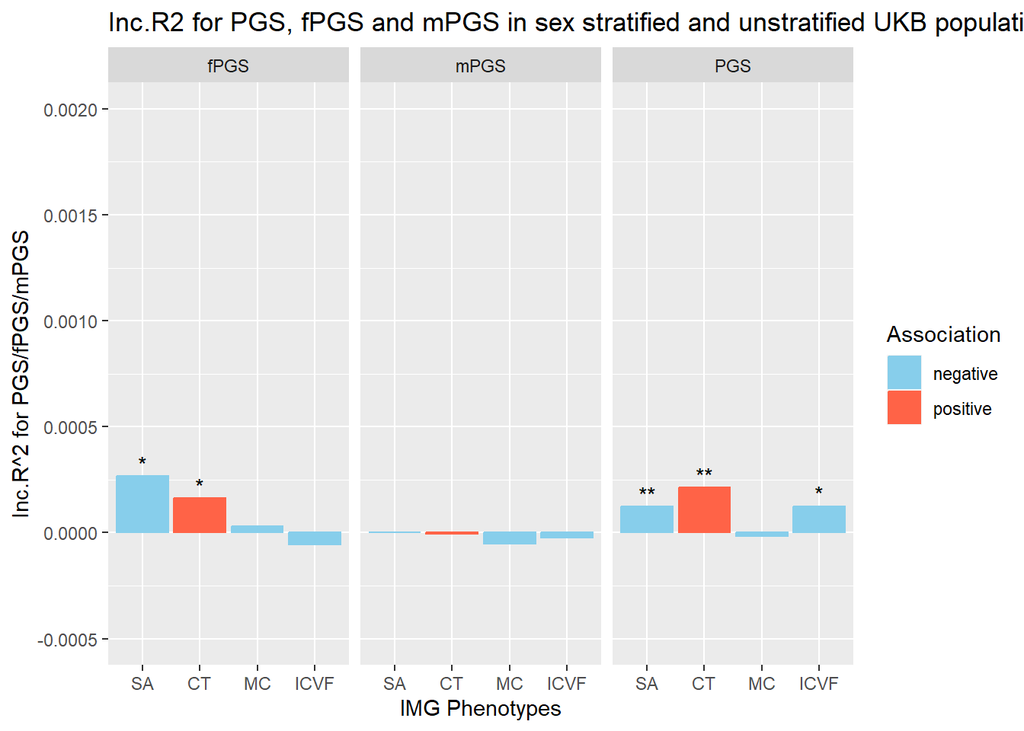

```r
inc.R2$Association <- c(rep("negative", 3), rep("positive", 3), rep("negative", 6)) # insert color after checking coefficient summary for lm
inc.R2$sig <- c(rep(c("**", "*", NA), 2), rep(NA, 3), "*", rep(NA, 2)) # same as above, insert sig annotation

# For PGS/fPGS/mPGS effect in unstratified, female and male population
inc.R2.fig <- ggplot(inc.R2, aes(y=R2, x= factor(IMG, levels = c("SA", "CT", "MC", "ICVF")), col = Association, fill = Association)) +
  geom_bar(position="dodge", stat="identity") + facet_wrap(~Label) + scale_fill_manual(values=c("skyblue", "tomato")) + scale_color_manual(values=c("skyblue", "tomato")) +
  labs(y = "Inc.R^2 for PGS/fPGS/mPGS", x = "IMG Phenotypes") +
  ggtitle("Inc.R2 for PGS, fPGS and mPGS in sex stratified and unstratified UKB population") + geom_text(aes(label = sig), col = "black", vjust = -0.25) + ylim(-5e-04, 2e-03)

inc.R2.fig
```

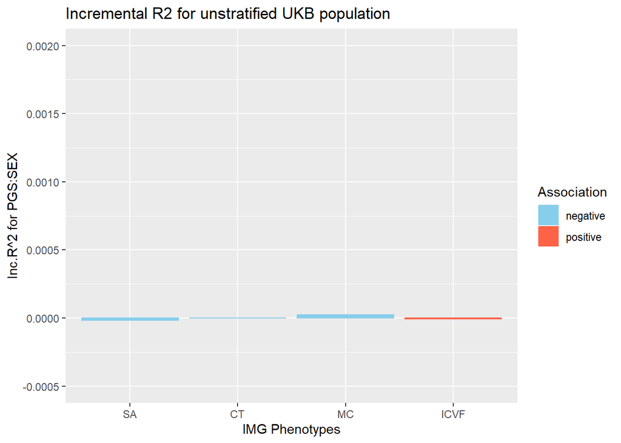

```r
#For PGS:Sex interaction effect in unstratified population
inc.R2.sex.interaction$Association <- c(rep("negative", 3), "positive") # insert color after checking coefficient summary for lm
# No sig PGS:SEX coefficient

inc.R2.sex.fig <- ggplot(inc.R2.sex.interaction, aes(y = R2, x = factor(IMG, levels = c("SA", "CT", "MC", "ICVF")), col = Association, fill = Association)) +
  geom_bar(position="dodge", stat="identity") + ggtitle("Incremental R2 for unstratified UKB population") + labs(x = "IMG Phenotypes", y = "Inc.R^2 for PGS:SEX") +
  scale_fill_manual(values=c("skyblue", "tomato")) + scale_color_manual(values=c("skyblue", "tomato")) + ylim(-5e-04, 2e-03)
inc.R2.sex.fig
```

```r
# VIF exceeding 5 or 10 indicates high multicollinearity between this independent variable and the others
# Age and Agesquared are highly colinear with each other is as expected. No fault found.

vif(PGS.Str_SA, type = "predictor")
```

```
## GVIFs computed for predictors
```

| GVIF | Df | GVIF^(1/(2*Df)) | Interacts With | Other Predictors |
| --- | --- | --- | --- | --- |
| 1 | 1 | 1 | -- | Sex, Age, Agesquared, X22009.0.1, X22009.0.2, X22009.0.3, X22009.0.4, X22009.0.5, X22009.0.6, X22009.0.7, X22009.0.8, X22009.0.9, X22009.0.10, Scan.Site, eulerleftplusright, fd, T1T2, batchID |
| 1.15 | 5 | 1.01 | Age, Agesquared | PGS_scaled, X22009.0.1, X22009.0.2, X22009.0.3, X22009.0.4, X22009.0.5, X22009.0.6, X22009.0.7, X22009.0.8, X22009.0.9, X22009.0.10, Scan.Site, eulerleftplusright, fd, T1T2, batchID |
| 6.48e+04 | 3 | 6.34 | Sex | PGS_scaled, Agesquared, X22009.0.1, X22009.0.2, X22009.0.3, X22009.0.4, X22009.0.5, X22009.0.6, X22009.0.7, X22009.0.8, X22009.0.9, X22009.0.10, Scan.Site, eulerleftplusright, fd, T1T2, batchID |
| 6.51e+04 | 3 | 6.34 | Sex | PGS_scaled, Age, X22009.0.1, X22009.0.2, X22009.0.3, X22009.0.4, X22009.0.5, X22009.0.6, X22009.0.7, X22009.0.8, X22009.0.9, X22009.0.10, Scan.Site, eulerleftplusright, fd, T1T2, batchID |
| 2.25 | 1 | 1.5 | -- | PGS_scaled, Sex, Age, Agesquared, X22009.0.2, X22009.0.3, X22009.0.4, X22009.0.5, X22009.0.6, X22009.0.7, X22009.0.8, X22009.0.9, X22009.0.10, Scan.Site, eulerleftplusright, fd, T1T2, batchID |
| 1.45 | 1 | 1.2 | -- | PGS_scaled, Sex, Age, Agesquared, X22009.0.1, X22009.0.3, X22009.0.4, X22009.0.5, X22009.0.6, X22009.0.7, X22009.0.8, X22009.0.9, X22009.0.10, Scan.Site, eulerleftplusright, fd, T1T2, batchID |
| 2.43 | 1 | 1.56 | -- | PGS_scaled, Sex, Age, Agesquared, X22009.0.1, X22009.0.2, X22009.0.4, X22009.0.5, X22009.0.6, X22009.0.7, X22009.0.8, X22009.0.9, X22009.0.10, Scan.Site, eulerleftplusright, fd, T1T2, batchID |
| 3.39 | 1 | 1.84 | -- | PGS_scaled, Sex, Age, Agesquared, X22009.0.1, X22009.0.2, X22009.0.3, X22009.0.5, X22009.0.6, X22009.0.7, X22009.0.8, X22009.0.9, X22009.0.10, Scan.Site, eulerleftplusright, fd, T1T2, batchID |
| 1.37 | 1 | 1.17 | -- | PGS_scaled, Sex, Age, Agesquared, X22009.0.1, X22009.0.2, X22009.0.3, X22009.0.4, X22009.0.6, X22009.0.7, X22009.0.8, X22009.0.9, X22009.0.10, Scan.Site, eulerleftplusright, fd, T1T2, batchID |
| 1.98 | 1 | 1.41 | -- | PGS_scaled, Sex, Age, Agesquared, X22009.0.1, X22009.0.2, X22009.0.3, X22009.0.4, X22009.0.5, X22009.0.7, X22009.0.8, X22009.0.9, X22009.0.10, Scan.Site, eulerleftplusright, fd, T1T2, batchID |
| 1.3 | 1 | 1.14 | -- | PGS_scaled, Sex, Age, Agesquared, X22009.0.1, X22009.0.2, X22009.0.3, X22009.0.4, X22009.0.5, X22009.0.6, X22009.0.8, X22009.0.9, X22009.0.10, Scan.Site, eulerleftplusright, fd, T1T2, batchID |
| 2.14 | 1 | 1.46 | -- | PGS_scaled, Sex, Age, Agesquared, X22009.0.1, X22009.0.2, X22009.0.3, X22009.0.4, X22009.0.5, X22009.0.6, X22009.0.7, X22009.0.9, X22009.0.10, Scan.Site, eulerleftplusright, fd, T1T2, batchID |
| 1.05 | 1 | 1.03 | -- | PGS_scaled, Sex, Age, Agesquared, X22009.0.1, X22009.0.2, X22009.0.3, X22009.0.4, X22009.0.5, X22009.0.6, X22009.0.7, X22009.0.8, X22009.0.10, Scan.Site, eulerleftplusright, fd, T1T2, batchID |
| 1.37 | 1 | 1.17 | -- | PGS_scaled, Sex, Age, Agesquared, X22009.0.1, X22009.0.2, X22009.0.3, X22009.0.4, X22009.0.5, X22009.0.6, X22009.0.7, X22009.0.8, X22009.0.9, Scan.Site, eulerleftplusright, fd, T1T2, batchID |
| 1.12 | 1 | 1.06 | -- | PGS_scaled, Sex, Age, Agesquared, X22009.0.1, X22009.0.2, X22009.0.3, X22009.0.4, X22009.0.5, X22009.0.6, X22009.0.7, X22009.0.8, X22009.0.9, X22009.0.10, eulerleftplusright, fd, T1T2, batchID |
| 1.2 | 1 | 1.09 | -- | PGS_scaled, Sex, Age, Agesquared, X22009.0.1, X22009.0.2, X22009.0.3, X22009.0.4, X22009.0.5, X22009.0.6, X22009.0.7, X22009.0.8, X22009.0.9, X22009.0.10, Scan.Site, fd, T1T2, batchID |
| 1.14 | 1 | 1.07 | -- | PGS_scaled, Sex, Age, Agesquared, X22009.0.1, X22009.0.2, X22009.0.3, X22009.0.4, X22009.0.5, X22009.0.6, X22009.0.7, X22009.0.8, X22009.0.9, X22009.0.10, Scan.Site, eulerleftplusright, T1T2, batchID |
| 1.01 | 1 | 1 | -- | PGS_scaled, Sex, Age, Agesquared, X22009.0.1, X22009.0.2, X22009.0.3, X22009.0.4, X22009.0.5, X22009.0.6, X22009.0.7, X22009.0.8, X22009.0.9, X22009.0.10, Scan.Site, eulerleftplusright, fd, batchID |
| 1 | 1 | 1 | -- | PGS_scaled, Sex, Age, Agesquared, X22009.0.1, X22009.0.2, X22009.0.3, X22009.0.4, X22009.0.5, X22009.0.6, X22009.0.7, X22009.0.8, X22009.0.9, X22009.0.10, Scan.Site, eulerleftplusright, fd, T1T2 |

```r
vif(PGS.Str_CT, type = "predictor")
```

```
## GVIFs computed for predictors
```

| GVIF | Df | GVIF^(1/(2*Df)) | Interacts With | Other Predictors |
| --- | --- | --- | --- | --- |
| 1 | 1 | 1 | -- | Sex, Age, Agesquared, X22009.0.1, X22009.0.2, X22009.0.3, X22009.0.4, X22009.0.5, X22009.0.6, X22009.0.7, X22009.0.8, X22009.0.9, X22009.0.10, Scan.Site, eulerleftplusright, fd, T1T2, batchID |
| 1.15 | 5 | 1.01 | Age, Agesquared | PGS_scaled, X22009.0.1, X22009.0.2, X22009.0.3, X22009.0.4, X22009.0.5, X22009.0.6, X22009.0.7, X22009.0.8, X22009.0.9, X22009.0.10, Scan.Site, eulerleftplusright, fd, T1T2, batchID |
| 6.48e+04 | 3 | 6.34 | Sex | PGS_scaled, Agesquared, X22009.0.1, X22009.0.2, X22009.0.3, X22009.0.4, X22009.0.5, X22009.0.6, X22009.0.7, X22009.0.8, X22009.0.9, X22009.0.10, Scan.Site, eulerleftplusright, fd, T1T2, batchID |
| 6.51e+04 | 3 | 6.34 | Sex | PGS_scaled, Age, X22009.0.1, X22009.0.2, X22009.0.3, X22009.0.4, X22009.0.5, X22009.0.6, X22009.0.7, X22009.0.8, X22009.0.9, X22009.0.10, Scan.Site, eulerleftplusright, fd, T1T2, batchID |
| 2.25 | 1 | 1.5 | -- | PGS_scaled, Sex, Age, Agesquared, X22009.0.2, X22009.0.3, X22009.0.4, X22009.0.5, X22009.0.6, X22009.0.7, X22009.0.8, X22009.0.9, X22009.0.10, Scan.Site, eulerleftplusright, fd, T1T2, batchID |
| 1.45 | 1 | 1.2 | -- | PGS_scaled, Sex, Age, Agesquared, X22009.0.1, X22009.0.3, X22009.0.4, X22009.0.5, X22009.0.6, X22009.0.7, X22009.0.8, X22009.0.9, X22009.0.10, Scan.Site, eulerleftplusright, fd, T1T2, batchID |
| 2.43 | 1 | 1.56 | -- | PGS_scaled, Sex, Age, Agesquared, X22009.0.1, X22009.0.2, X22009.0.4, X22009.0.5, X22009.0.6, X22009.0.7, X22009.0.8, X22009.0.9, X22009.0.10, Scan.Site, eulerleftplusright, fd, T1T2, batchID |
| 3.39 | 1 | 1.84 | -- | PGS_scaled, Sex, Age, Agesquared, X22009.0.1, X22009.0.2, X22009.0.3, X22009.0.5, X22009.0.6, X22009.0.7, X22009.0.8, X22009.0.9, X22009.0.10, Scan.Site, eulerleftplusright, fd, T1T2, batchID |
| 1.37 | 1 | 1.17 | -- | PGS_scaled, Sex, Age, Agesquared, X22009.0.1, X22009.0.2, X22009.0.3, X22009.0.4, X22009.0.6, X22009.0.7, X22009.0.8, X22009.0.9, X22009.0.10, Scan.Site, eulerleftplusright, fd, T1T2, batchID |
| 1.98 | 1 | 1.41 | -- | PGS_scaled, Sex, Age, Agesquared, X22009.0.1, X22009.0.2, X22009.0.3, X22009.0.4, X22009.0.5, X22009.0.7, X22009.0.8, X22009.0.9, X22009.0.10, Scan.Site, eulerleftplusright, fd, T1T2, batchID |
| 1.3 | 1 | 1.14 | -- | PGS_scaled, Sex, Age, Agesquared, X22009.0.1, X22009.0.2, X22009.0.3, X22009.0.4, X22009.0.5, X22009.0.6, X22009.0.8, X22009.0.9, X22009.0.10, Scan.Site, eulerleftplusright, fd, T1T2, batchID |
| 2.14 | 1 | 1.46 | -- | PGS_scaled, Sex, Age, Agesquared, X22009.0.1, X22009.0.2, X22009.0.3, X22009.0.4, X22009.0.5, X22009.0.6, X22009.0.7, X22009.0.9, X22009.0.10, Scan.Site, eulerleftplusright, fd, T1T2, batchID |
| 1.05 | 1 | 1.03 | -- | PGS_scaled, Sex, Age, Agesquared, X22009.0.1, X22009.0.2, X22009.0.3, X22009.0.4, X22009.0.5, X22009.0.6, X22009.0.7, X22009.0.8, X22009.0.10, Scan.Site, eulerleftplusright, fd, T1T2, batchID |
| 1.37 | 1 | 1.17 | -- | PGS_scaled, Sex, Age, Agesquared, X22009.0.1, X22009.0.2, X22009.0.3, X22009.0.4, X22009.0.5, X22009.0.6, X22009.0.7, X22009.0.8, X22009.0.9, Scan.Site, eulerleftplusright, fd, T1T2, batchID |
| 1.12 | 1 | 1.06 | -- | PGS_scaled, Sex, Age, Agesquared, X22009.0.1, X22009.0.2, X22009.0.3, X22009.0.4, X22009.0.5, X22009.0.6, X22009.0.7, X22009.0.8, X22009.0.9, X22009.0.10, eulerleftplusright, fd, T1T2, batchID |
| 1.2 | 1 | 1.09 | -- | PGS_scaled, Sex, Age, Agesquared, X22009.0.1, X22009.0.2, X22009.0.3, X22009.0.4, X22009.0.5, X22009.0.6, X22009.0.7, X22009.0.8, X22009.0.9, X22009.0.10, Scan.Site, fd, T1T2, batchID |
| 1.14 | 1 | 1.07 | -- | PGS_scaled, Sex, Age, Agesquared, X22009.0.1, X22009.0.2, X22009.0.3, X22009.0.4, X22009.0.5, X22009.0.6, X22009.0.7, X22009.0.8, X22009.0.9, X22009.0.10, Scan.Site, eulerleftplusright, T1T2, batchID |
| 1.01 | 1 | 1 | -- | PGS_scaled, Sex, Age, Agesquared, X22009.0.1, X22009.0.2, X22009.0.3, X22009.0.4, X22009.0.5, X22009.0.6, X22009.0.7, X22009.0.8, X22009.0.9, X22009.0.10, Scan.Site, eulerleftplusright, fd, batchID |
| 1 | 1 | 1 | -- | PGS_scaled, Sex, Age, Agesquared, X22009.0.1, X22009.0.2, X22009.0.3, X22009.0.4, X22009.0.5, X22009.0.6, X22009.0.7, X22009.0.8, X22009.0.9, X22009.0.10, Scan.Site, eulerleftplusright, fd, T1T2 |

```r
vif(PGS.Str_MC, type = "predictor")
```

```
## GVIFs computed for predictors
```

| GVIF | Df | GVIF^(1/(2*Df)) | Interacts With | Other Predictors |
| --- | --- | --- | --- | --- |
| 1 | 1 | 1 | -- | Sex, Age, Agesquared, X22009.0.1, X22009.0.2, X22009.0.3, X22009.0.4, X22009.0.5, X22009.0.6, X22009.0.7, X22009.0.8, X22009.0.9, X22009.0.10, Scan.Site, eulerleftplusright, fd, T1T2, batchID |
| 1.15 | 5 | 1.01 | Age, Agesquared | PGS_scaled, X22009.0.1, X22009.0.2, X22009.0.3, X22009.0.4, X22009.0.5, X22009.0.6, X22009.0.7, X22009.0.8, X22009.0.9, X22009.0.10, Scan.Site, eulerleftplusright, fd, T1T2, batchID |
| 6.48e+04 | 3 | 6.34 | Sex | PGS_scaled, Agesquared, X22009.0.1, X22009.0.2, X22009.0.3, X22009.0.4, X22009.0.5, X22009.0.6, X22009.0.7, X22009.0.8, X22009.0.9, X22009.0.10, Scan.Site, eulerleftplusright, fd, T1T2, batchID |
| 6.51e+04 | 3 | 6.34 | Sex | PGS_scaled, Age, X22009.0.1, X22009.0.2, X22009.0.3, X22009.0.4, X22009.0.5, X22009.0.6, X22009.0.7, X22009.0.8, X22009.0.9, X22009.0.10, Scan.Site, eulerleftplusright, fd, T1T2, batchID |
| 2.25 | 1 | 1.5 | -- | PGS_scaled, Sex, Age, Agesquared, X22009.0.2, X22009.0.3, X22009.0.4, X22009.0.5, X22009.0.6, X22009.0.7, X22009.0.8, X22009.0.9, X22009.0.10, Scan.Site, eulerleftplusright, fd, T1T2, batchID |
| 1.45 | 1 | 1.2 | -- | PGS_scaled, Sex, Age, Agesquared, X22009.0.1, X22009.0.3, X22009.0.4, X22009.0.5, X22009.0.6, X22009.0.7, X22009.0.8, X22009.0.9, X22009.0.10, Scan.Site, eulerleftplusright, fd, T1T2, batchID |
| 2.43 | 1 | 1.56 | -- | PGS_scaled, Sex, Age, Agesquared, X22009.0.1, X22009.0.2, X22009.0.4, X22009.0.5, X22009.0.6, X22009.0.7, X22009.0.8, X22009.0.9, X22009.0.10, Scan.Site, eulerleftplusright, fd, T1T2, batchID |
| 3.39 | 1 | 1.84 | -- | PGS_scaled, Sex, Age, Agesquared, X22009.0.1, X22009.0.2, X22009.0.3, X22009.0.5, X22009.0.6, X22009.0.7, X22009.0.8, X22009.0.9, X22009.0.10, Scan.Site, eulerleftplusright, fd, T1T2, batchID |
| 1.37 | 1 | 1.17 | -- | PGS_scaled, Sex, Age, Agesquared, X22009.0.1, X22009.0.2, X22009.0.3, X22009.0.4, X22009.0.6, X22009.0.7, X22009.0.8, X22009.0.9, X22009.0.10, Scan.Site, eulerleftplusright, fd, T1T2, batchID |
| 1.98 | 1 | 1.41 | -- | PGS_scaled, Sex, Age, Agesquared, X22009.0.1, X22009.0.2, X22009.0.3, X22009.0.4, X22009.0.5, X22009.0.7, X22009.0.8, X22009.0.9, X22009.0.10, Scan.Site, eulerleftplusright, fd, T1T2, batchID |
| 1.3 | 1 | 1.14 | -- | PGS_scaled, Sex, Age, Agesquared, X22009.0.1, X22009.0.2, X22009.0.3, X22009.0.4, X22009.0.5, X22009.0.6, X22009.0.8, X22009.0.9, X22009.0.10, Scan.Site, eulerleftplusright, fd, T1T2, batchID |
| 2.14 | 1 | 1.46 | -- | PGS_scaled, Sex, Age, Agesquared, X22009.0.1, X22009.0.2, X22009.0.3, X22009.0.4, X22009.0.5, X22009.0.6, X22009.0.7, X22009.0.9, X22009.0.10, Scan.Site, eulerleftplusright, fd, T1T2, batchID |
| 1.05 | 1 | 1.03 | -- | PGS_scaled, Sex, Age, Agesquared, X22009.0.1, X22009.0.2, X22009.0.3, X22009.0.4, X22009.0.5, X22009.0.6, X22009.0.7, X22009.0.8, X22009.0.10, Scan.Site, eulerleftplusright, fd, T1T2, batchID |
| 1.37 | 1 | 1.17 | -- | PGS_scaled, Sex, Age, Agesquared, X22009.0.1, X22009.0.2, X22009.0.3, X22009.0.4, X22009.0.5, X22009.0.6, X22009.0.7, X22009.0.8, X22009.0.9, Scan.Site, eulerleftplusright, fd, T1T2, batchID |
| 1.12 | 1 | 1.06 | -- | PGS_scaled, Sex, Age, Agesquared, X22009.0.1, X22009.0.2, X22009.0.3, X22009.0.4, X22009.0.5, X22009.0.6, X22009.0.7, X22009.0.8, X22009.0.9, X22009.0.10, eulerleftplusright, fd, T1T2, batchID |
| 1.2 | 1 | 1.09 | -- | PGS_scaled, Sex, Age, Agesquared, X22009.0.1, X22009.0.2, X22009.0.3, X22009.0.4, X22009.0.5, X22009.0.6, X22009.0.7, X22009.0.8, X22009.0.9, X22009.0.10, Scan.Site, fd, T1T2, batchID |
| 1.14 | 1 | 1.07 | -- | PGS_scaled, Sex, Age, Agesquared, X22009.0.1, X22009.0.2, X22009.0.3, X22009.0.4, X22009.0.5, X22009.0.6, X22009.0.7, X22009.0.8, X22009.0.9, X22009.0.10, Scan.Site, eulerleftplusright, T1T2, batchID |
| 1.01 | 1 | 1 | -- | PGS_scaled, Sex, Age, Agesquared, X22009.0.1, X22009.0.2, X22009.0.3, X22009.0.4, X22009.0.5, X22009.0.6, X22009.0.7, X22009.0.8, X22009.0.9, X22009.0.10, Scan.Site, eulerleftplusright, fd, batchID |
| 1 | 1 | 1 | -- | PGS_scaled, Sex, Age, Agesquared, X22009.0.1, X22009.0.2, X22009.0.3, X22009.0.4, X22009.0.5, X22009.0.6, X22009.0.7, X22009.0.8, X22009.0.9, X22009.0.10, Scan.Site, eulerleftplusright, fd, T1T2 |

```r
vif(PGS.ICVF, type = "predictor")
```

```
## GVIFs computed for predictors
```

| GVIF | Df | GVIF^(1/(2*Df)) | Interacts With | Other Predictors |
| --- | --- | --- | --- | --- |
| 1 | 1 | 1 | -- | Sex, Age, Agesquared, X22009.0.1, X22009.0.2, X22009.0.3, X22009.0.4, X22009.0.5, X22009.0.6, X22009.0.7, X22009.0.8, X22009.0.9, X22009.0.10, Scan.Site, eulerleftplusright, fd, batchID |
| 1.15 | 5 | 1.01 | Age, Agesquared | PGS_scaled, X22009.0.1, X22009.0.2, X22009.0.3, X22009.0.4, X22009.0.5, X22009.0.6, X22009.0.7, X22009.0.8, X22009.0.9, X22009.0.10, Scan.Site, eulerleftplusright, fd, batchID |
| 6.49e+04 | 3 | 6.34 | Sex | PGS_scaled, Agesquared, X22009.0.1, X22009.0.2, X22009.0.3, X22009.0.4, X22009.0.5, X22009.0.6, X22009.0.7, X22009.0.8, X22009.0.9, X22009.0.10, Scan.Site, eulerleftplusright, fd, batchID |
| 6.51e+04 | 3 | 6.34 | Sex | PGS_scaled, Age, X22009.0.1, X22009.0.2, X22009.0.3, X22009.0.4, X22009.0.5, X22009.0.6, X22009.0.7, X22009.0.8, X22009.0.9, X22009.0.10, Scan.Site, eulerleftplusright, fd, batchID |
| 2.25 | 1 | 1.5 | -- | PGS_scaled, Sex, Age, Agesquared, X22009.0.2, X22009.0.3, X22009.0.4, X22009.0.5, X22009.0.6, X22009.0.7, X22009.0.8, X22009.0.9, X22009.0.10, Scan.Site, eulerleftplusright, fd, batchID |
| 1.45 | 1 | 1.2 | -- | PGS_scaled, Sex, Age, Agesquared, X22009.0.1, X22009.0.3, X22009.0.4, X22009.0.5, X22009.0.6, X22009.0.7, X22009.0.8, X22009.0.9, X22009.0.10, Scan.Site, eulerleftplusright, fd, batchID |
| 2.43 | 1 | 1.56 | -- | PGS_scaled, Sex, Age, Agesquared, X22009.0.1, X22009.0.2, X22009.0.4, X22009.0.5, X22009.0.6, X22009.0.7, X22009.0.8, X22009.0.9, X22009.0.10, Scan.Site, eulerleftplusright, fd, batchID |
| 3.39 | 1 | 1.84 | -- | PGS_scaled, Sex, Age, Agesquared, X22009.0.1, X22009.0.2, X22009.0.3, X22009.0.5, X22009.0.6, X22009.0.7, X22009.0.8, X22009.0.9, X22009.0.10, Scan.Site, eulerleftplusright, fd, batchID |
| 1.37 | 1 | 1.17 | -- | PGS_scaled, Sex, Age, Agesquared, X22009.0.1, X22009.0.2, X22009.0.3, X22009.0.4, X22009.0.6, X22009.0.7, X22009.0.8, X22009.0.9, X22009.0.10, Scan.Site, eulerleftplusright, fd, batchID |
| 1.98 | 1 | 1.41 | -- | PGS_scaled, Sex, Age, Agesquared, X22009.0.1, X22009.0.2, X22009.0.3, X22009.0.4, X22009.0.5, X22009.0.7, X22009.0.8, X22009.0.9, X22009.0.10, Scan.Site, eulerleftplusright, fd, batchID |
| 1.3 | 1 | 1.14 | -- | PGS_scaled, Sex, Age, Agesquared, X22009.0.1, X22009.0.2, X22009.0.3, X22009.0.4, X22009.0.5, X22009.0.6, X22009.0.8, X22009.0.9, X22009.0.10, Scan.Site, eulerleftplusright, fd, batchID |
| 2.14 | 1 | 1.46 | -- | PGS_scaled, Sex, Age, Agesquared, X22009.0.1, X22009.0.2, X22009.0.3, X22009.0.4, X22009.0.5, X22009.0.6, X22009.0.7, X22009.0.9, X22009.0.10, Scan.Site, eulerleftplusright, fd, batchID |
| 1.05 | 1 | 1.03 | -- | PGS_scaled, Sex, Age, Agesquared, X22009.0.1, X22009.0.2, X22009.0.3, X22009.0.4, X22009.0.5, X22009.0.6, X22009.0.7, X22009.0.8, X22009.0.10, Scan.Site, eulerleftplusright, fd, batchID |
| 1.37 | 1 | 1.17 | -- | PGS_scaled, Sex, Age, Agesquared, X22009.0.1, X22009.0.2, X22009.0.3, X22009.0.4, X22009.0.5, X22009.0.6, X22009.0.7, X22009.0.8, X22009.0.9, Scan.Site, eulerleftplusright, fd, batchID |
| 1.12 | 1 | 1.06 | -- | PGS_scaled, Sex, Age, Agesquared, X22009.0.1, X22009.0.2, X22009.0.3, X22009.0.4, X22009.0.5, X22009.0.6, X22009.0.7, X22009.0.8, X22009.0.9, X22009.0.10, eulerleftplusright, fd, batchID |
| 1.2 | 1 | 1.09 | -- | PGS_scaled, Sex, Age, Agesquared, X22009.0.1, X22009.0.2, X22009.0.3, X22009.0.4, X22009.0.5, X22009.0.6, X22009.0.7, X22009.0.8, X22009.0.9, X22009.0.10, Scan.Site, fd, batchID |
| 1.13 | 1 | 1.06 | -- | PGS_scaled, Sex, Age, Agesquared, X22009.0.1, X22009.0.2, X22009.0.3, X22009.0.4, X22009.0.5, X22009.0.6, X22009.0.7, X22009.0.8, X22009.0.9, X22009.0.10, Scan.Site, eulerleftplusright, batchID |
| 1 | 1 | 1 | -- | PGS_scaled, Sex, Age, Agesquared, X22009.0.1, X22009.0.2, X22009.0.3, X22009.0.4, X22009.0.5, X22009.0.6, X22009.0.7, X22009.0.8, X22009.0.9, X22009.0.10, Scan.Site, eulerleftplusright, fd |

```r
vif(fPGS.Str_SA)
```

```
##        fPGS_scaled                Age         Agesquared         X22009.0.1
##           1.002798         254.132361         255.296407           2.234244
##         X22009.0.2         X22009.0.3         X22009.0.4         X22009.0.5
##           1.476002           2.363239           3.363340           1.362274
##         X22009.0.6         X22009.0.7         X22009.0.8         X22009.0.9
##           2.166817           1.403032           2.330573           1.055785
##        X22009.0.10          Scan.Site eulerleftplusright                 fd
##           1.406734           1.136265           1.151472           1.105065
##               T1T2            batchID
##           1.006321           1.002452
```

```r
vif(fPGS.Str_CT)
```

```
##        fPGS_scaled                Age         Agesquared         X22009.0.1
##           1.002802         254.140153         255.304197           2.234263
##         X22009.0.2         X22009.0.3         X22009.0.4         X22009.0.5
##           1.475991           2.363231           3.363331           1.362284
##         X22009.0.6         X22009.0.7         X22009.0.8         X22009.0.9
##           2.166799           1.403017           2.330520           1.055782
##        X22009.0.10          Scan.Site eulerleftplusright                 fd
##           1.406720           1.136239           1.151479           1.105063
##               T1T2            batchID
##           1.006321           1.002446
```

```r
vif(fPGS.Str_MC)
```

```
##        fPGS_scaled                Age         Agesquared         X22009.0.1
##           1.002804         254.157879         255.325152           2.234533
##         X22009.0.2         X22009.0.3         X22009.0.4         X22009.0.5
##           1.475965           2.363212           3.363448           1.362248
##         X22009.0.6         X22009.0.7         X22009.0.8         X22009.0.9
##           2.166803           1.403018           2.330522           1.055787
##        X22009.0.10          Scan.Site eulerleftplusright                 fd
##           1.406833           1.136309           1.151996           1.105271
##               T1T2            batchID
##           1.006321           1.002441
```

```r
vif(fPGS.ICVF)
```

```
##        fPGS_scaled                Age         Agesquared         X22009.0.1
##           1.002784         254.270537         255.428438           2.236912
##         X22009.0.2         X22009.0.3         X22009.0.4         X22009.0.5
##           1.475509           2.367924           3.369884           1.361560
##         X22009.0.6         X22009.0.7         X22009.0.8         X22009.0.9
##           2.167592           1.402055           2.329688           1.055518
##        X22009.0.10          Scan.Site eulerleftplusright                 fd
##           1.406251           1.132224           1.149789           1.103169
##            batchID
##           1.002116
```

```r
vif(mPGS.Str_SA)
```

```
##        mPGS_scaled                Age         Agesquared         X22009.0.1
##           1.003824         252.699000         253.811738           2.282328
##         X22009.0.2         X22009.0.3         X22009.0.4         X22009.0.5
##           1.428009           2.523369           3.422926           1.377368
##         X22009.0.6         X22009.0.7         X22009.0.8         X22009.0.9
##           1.773596           1.197310           1.924418           1.046846
##        X22009.0.10          Scan.Site eulerleftplusright                 fd
##           1.335562           1.111748           1.212295           1.124079
##               T1T2            batchID
##           1.006773           1.002246
```

```r
vif(mPGS.Str_CT)
```

```
##        mPGS_scaled                Age         Agesquared         X22009.0.1
##           1.003819         252.683716         253.797292           2.282440
##         X22009.0.2         X22009.0.3         X22009.0.4         X22009.0.5
##           1.428017           2.523397           3.422916           1.377290
##         X22009.0.6         X22009.0.7         X22009.0.8         X22009.0.9
##           1.773480           1.197300           1.924360           1.046831
##        X22009.0.10          Scan.Site eulerleftplusright                 fd
##           1.335576           1.111708           1.212308           1.124079
##               T1T2            batchID
##           1.006785           1.002251
```

```r
vif(mPGS.Str_MC)
```

[output not shown]

```r
vif(mPGS.ICVF)
```

```
##        mPGS_scaled                Age         Agesquared         X22009.0.1
##           1.003817         252.577485         253.683398           2.277667
##         X22009.0.2         X22009.0.3         X22009.0.4         X22009.0.5
##           1.426540           2.516818           3.415960           1.378209
##         X22009.0.6         X22009.0.7         X22009.0.8         X22009.0.9
##           1.773524           1.197633           1.925025           1.046903
##        X22009.0.10          Scan.Site eulerleftplusright                 fd
##           1.336313           1.107055           1.211473           1.123969
##            batchID
##           1.002156
```

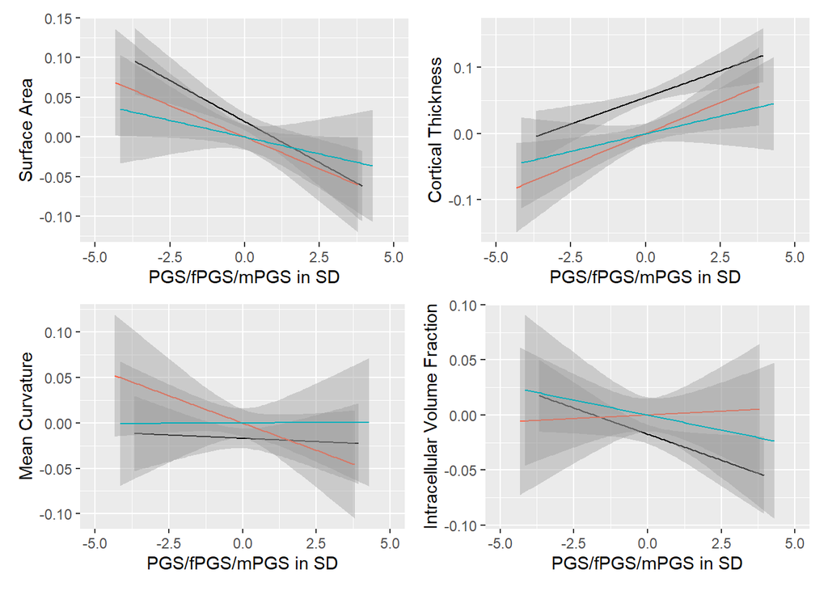

```r
# visualise linear regression
# Black = unstratified; tomato = Female; #00AFBB = Male
# For SA
PGS.SA.lm.vis <- ggplot(PGS.Str_SA, aes(PGS_scaled, Struct_SA)) + geom_smooth(method = "lm", colour = "black", linewidth = 0.5) +
  stat_smooth(data = fPGS.Str_SA, inherit.aes = FALSE, aes(fPGS_scaled, Struct_SA), method = "lm", colour = "tomato", linewidth = 0.5) +
  stat_smooth(data = mPGS.Str_SA, inherit.aes = FALSE, aes(mPGS_scaled, Struct_SA), method = "lm", colour = "#00AFBB", linewidth = 0.5) + xlim(-5,5) +
  labs(y = "Surface Area", x = "PGS/fPGS/mPGS in SD")

# For CT
PGS.CT.lm.vis <- ggplot(PGS.Str_CT, aes(PGS_scaled, Struct_CT)) + geom_smooth(method = "lm", colour = "black", linewidth = 0.5) +
  stat_smooth(data = fPGS.Str_CT, inherit.aes = FALSE, aes(fPGS_scaled, Struct_CT), method = "lm", colour = "tomato", linewidth = 0.5) +
  stat_smooth(data = mPGS.Str_CT, inherit.aes = FALSE, aes(mPGS_scaled, Struct_CT), method = "lm", colour = "#00AFBB", linewidth = 0.5) + xlim(-5,5) +
  labs(y = "Cortical Thickness", x = "PGS/fPGS/mPGS in SD")

# For MC
PGS.MC.lm.vis <- ggplot(PGS.Str_MC, aes(PGS_scaled, Struct_meanCurv)) + geom_smooth(method = "lm", colour = "black", linewidth = 0.5) +
  stat_smooth(data = fPGS.Str_MC, inherit.aes = FALSE, aes(fPGS_scaled, Struct_meanCurv), method = "lm", colour = "tomato", linewidth = 0.5) +
  stat_smooth(data = mPGS.Str_MC, inherit.aes = FALSE, aes(mPGS_scaled, Struct_meanCurv), method = "lm", colour = "#00AFBB", linewidth = 0.5) + xlim(-5,5) +
  labs(y = "Mean Curvature", x = "PGS/fPGS/mPGS in SD")

# For ICVF
PGS.ICVF.lm.vis <- ggplot(PGS.ICVF, aes(PGS_scaled, meanNODDI_ICVF)) + geom_smooth(method = "lm", colour = "black", linewidth = 0.5) +
  stat_smooth(data = fPGS.ICVF, inherit.aes = FALSE, aes(fPGS_scaled, meanNODDI_ICVF), method = "lm", colour = "tomato", linewidth = 0.5) +
  stat_smooth(data = mPGS.ICVF, inherit.aes = FALSE, aes(mPGS_scaled, meanNODDI_ICVF), method = "lm", colour = "#00AFBB", linewidth = 0.5) + xlim(-5,5) +
  labs(y = "Intracellular Volume Fraction", x = "PGS/fPGS/mPGS in SD")

PGS.IMG.lm.ALL <- (PGS.SA.lm.vis | PGS.CT.lm.vis) / (PGS.MC.lm.vis| PGS.ICVF.lm.vis)
PGS.IMG.lm.ALL
```

```r
# PROBLEM: Will remove so many points if I try to set a ylim, how to fix it?
```

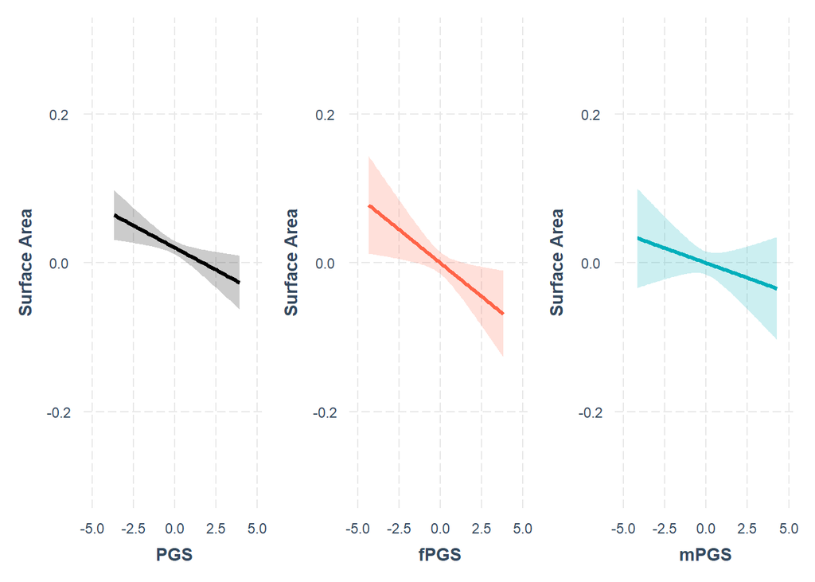

```r
PGS.eff.SA <-  effect_plot(PGS.Str_SA, pred = PGS_scaled, interval = TRUE, colors ="Black") + xlim(-5,5) + ylim(-0.3,0.3) + labs(y = "Surface Area", x = "PGS")
fPGS.eff.SA <- effect_plot(fPGS.Str_SA, pred = fPGS_scaled, interval = TRUE, colors ="tomato") + xlim(-5,5) + ylim(-0.3,0.3) + labs(y = "Surface Area", x = "fPGS")
mPGS.eff.SA <- effect_plot(mPGS.Str_SA, pred = mPGS_scaled, interval = TRUE, colors ="#00AFBB") + xlim(-5,5) + ylim(-0.3,0.3) + labs(y = "Surface Area", x = "mPGS")
effSA <- PGS.eff.SA + fPGS.eff.SA + mPGS.eff.SA
effSA
```

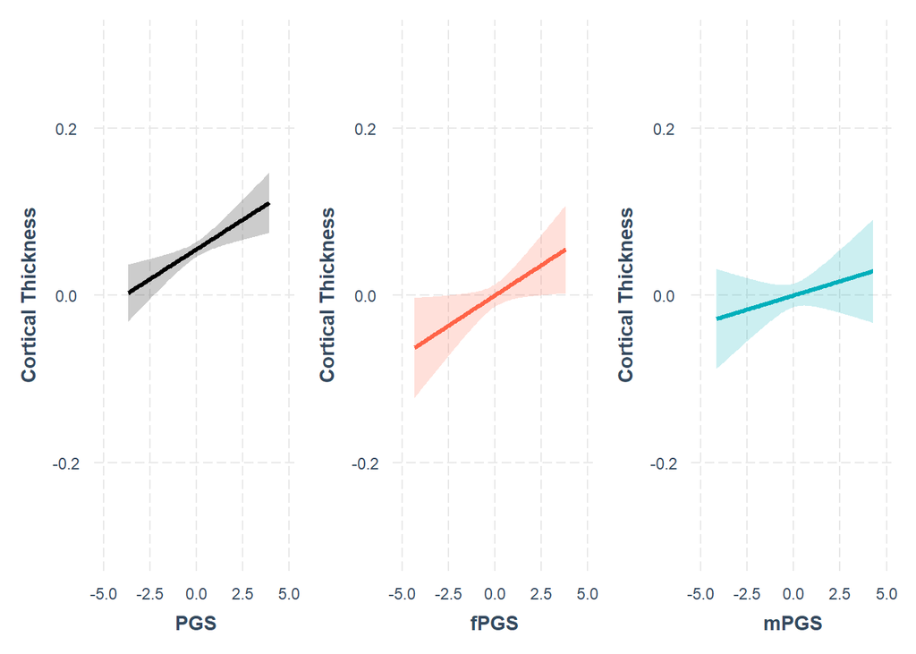

```r
PGS.eff.CT <- effect_plot(PGS.Str_CT, pred = PGS_scaled, interval = TRUE) + xlim(-5,5) + ylim(-0.3,0.3) + labs(y = "Cortical Thickness", x = "PGS")
fPGS.eff.CT <- effect_plot(fPGS.Str_CT, pred = fPGS_scaled, interval = TRUE, colors ="tomato") + xlim(-5,5) + ylim(-0.3,0.3) + labs(y = "Cortical Thickness", x = "fPGS")
mPGS.eff.CT <- effect_plot(mPGS.Str_CT, pred = mPGS_scaled, interval = TRUE, colors ="#00AFBB")+ xlim(-5,5) + ylim(-0.3,0.3) + labs(y = "Cortical Thickness", x = "mPGS")
effCT <- PGS.eff.CT + fPGS.eff.CT + mPGS.eff.CT
effCT
```

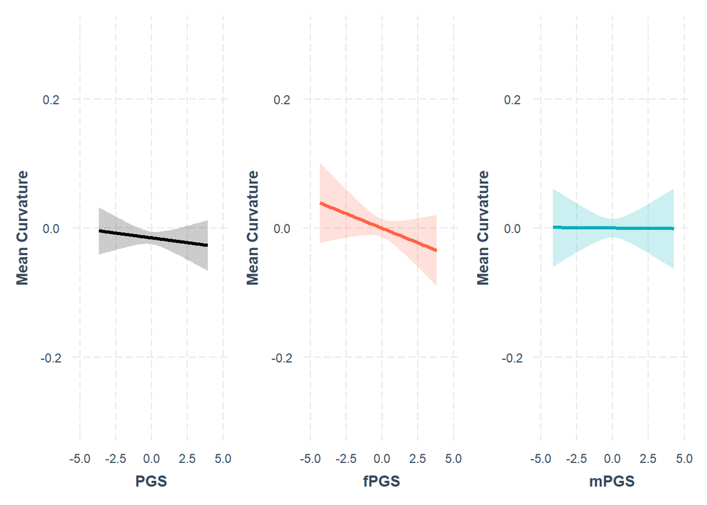

```r
PGS.eff.MC <- effect_plot(PGS.Str_MC, pred = PGS_scaled, interval = TRUE) + xlim(-5,5) + ylim(-0.3,0.3) + labs(y = "Mean Curvature", x = "PGS")
fPGS.eff.MC <- effect_plot(fPGS.Str_MC, pred = fPGS_scaled, interval = TRUE, colors ="tomato") + xlim(-5,5) + ylim(-0.3,0.3) + labs(y = "Mean Curvature", x = "fPGS")
mPGS.eff.MC <- effect_plot(mPGS.Str_MC, pred = mPGS_scaled, interval = TRUE, colors ="#00AFBB")+ xlim(-5,5) + ylim(-0.3,0.3) + labs(y = "Mean Curvature", x = "mPGS")
effMC <- PGS.eff.MC + fPGS.eff.MC + mPGS.eff.MC
effMC
```

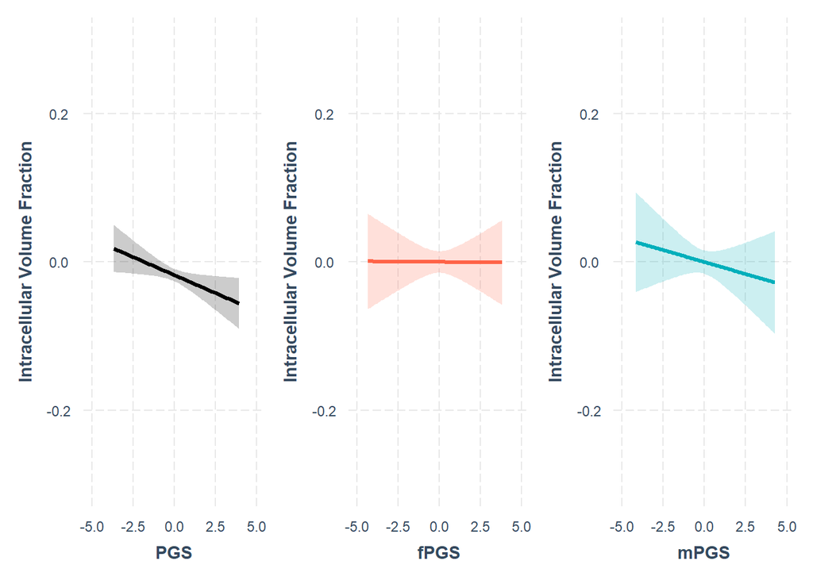

```r
PGS.eff.ICVF <- effect_plot(PGS.ICVF, pred = PGS_scaled, interval = TRUE) + xlim(-5,5) + ylim(-0.3,0.3) + labs(y = "Intracellular Volume Fraction", x = "PGS")
fPGS.eff.ICVF <- effect_plot(fPGS.ICVF, pred = fPGS_scaled, interval = TRUE, colors ="tomato") + xlim(-5,5) + ylim(-0.3,0.3) + labs(y = "Intracellular Volume Fraction", x = "fPGS")
mPGS.eff.ICVF <- effect_plot(mPGS.ICVF, pred = mPGS_scaled, interval = TRUE, colors ="#00AFBB") + xlim(-5,5) + ylim(-0.3,0.3) + labs(y = "Intracellular Volume Fraction", x = "mPGS")
effICVF <- PGS.eff.ICVF + fPGS.eff.ICVF + mPGS.eff.ICVF
effICVF
```

```r
# I've tried but effect_plot doesn't support plotting multiple graph together, and in order to change it I'll need deep understanding of his code and make it work.
# From the source code I've located his key function on using make_prediction() but I couldn't fully understand his ggplot2 code.
# I'm running out of time for this week, I'll come back later but at my current of R coding level I don't feel I can do much.
```

# Study of Regional Phenotype effect through Linear fixed effect models and summary

# Regional Inc.R2 model loop, calculation and visualisation

# Regional Inc.R2 Calculation and calculation (NEED DOUBLE CHECK)

```r
# For loop to read in all with PGS and without PGS/fPGS/mPGS/PGS:SEX models
R2.reg.list <- paste0(here("Results/", list.files(path = here("Results/"), pattern = "*_with_Glb.*"))) # Grab file directories
R2.reg.list2 <- c(here("Results//reg.pgs.SA.txt"), here("Results//reg.pgs.CT.txt"), here("Results//reg.pgs.MC.txt"), here("Results//reg.pgs.ICVF.txt"))
R2.reg.list3 <- paste0(here("Results/", list.files(path = here("Results/"), pattern = "*_updated.txt")))
R2.reg.list <- c(R2.reg.list,R2.reg.list2,R2.reg.list3)

for (i in 1:length(R2.reg.list)) {
  df = fread(R2.reg.list[i])
  df_name = sub("C:/Users/yg330/OneDrive - University of Cambridge/Documents/Projects/pgs_img/Results//", "" , R2.reg.list[i])
  df_name = sub(".txt", "", df_name)
  assign(df_name, df)
}
```

```r
# For Reg.IMG~PGS
PGS.reg.pgs.SA_updated$Inc.R2 <- PGS.reg.pgs.SA_updated$R2 - reg.pgs.SA$R2
PGS.reg.pgs.CT_updated$Inc.R2 <- PGS.reg.pgs.CT_updated$R2 - reg.pgs.CT$R2
PGS.reg.pgs.MC_updated$Inc.R2 <- PGS.reg.pgs.MC_updated$R2 - reg.pgs.MC$R2
PGS.reg.pgs.ICVF_updated$Inc.R2 <- PGS.reg.pgs.ICVF_updated$R2 - reg.pgs.ICVF$R2

summary(PGS.reg.pgs.SA_updated$Inc.R2)
```

```
##       Min.    1st Qu.     Median       Mean    3rd Qu.       Max.
## -2.809e-05 -3.056e-06  3.304e-05  6.256e-05  9.839e-05  3.786e-04
```

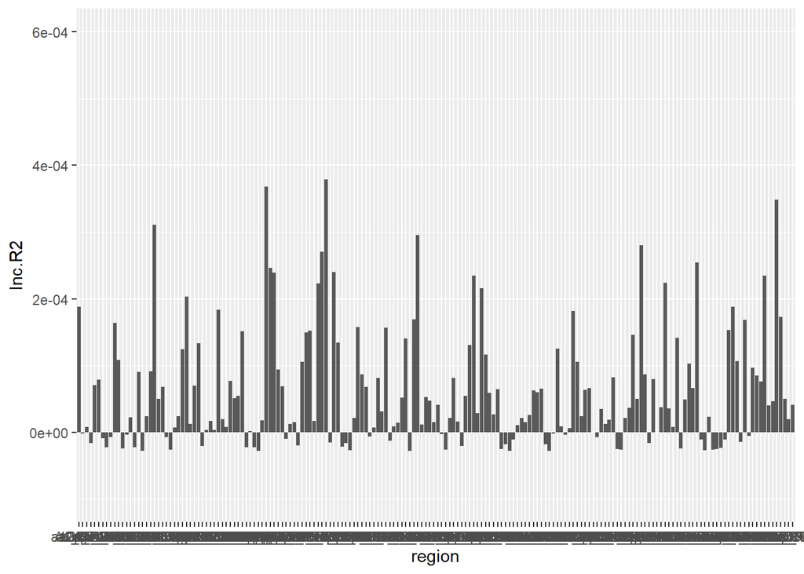

```r
vis.IncR2.SA <- ggplot(PGS.reg.pgs.SA_updated, aes(x=region, y=Inc.R2)) + geom_bar(stat="identity") + ylim(-0.0001, 0.0006)
vis.IncR2.SA
```

```r
summary(PGS.reg.pgs.CT_updated$Inc.R2)
```

```
##       Min.    1st Qu.     Median       Mean    3rd Qu.       Max.
## -3.099e-05 -1.887e-06  2.827e-05  5.250e-05  9.624e-05  3.343e-04
```

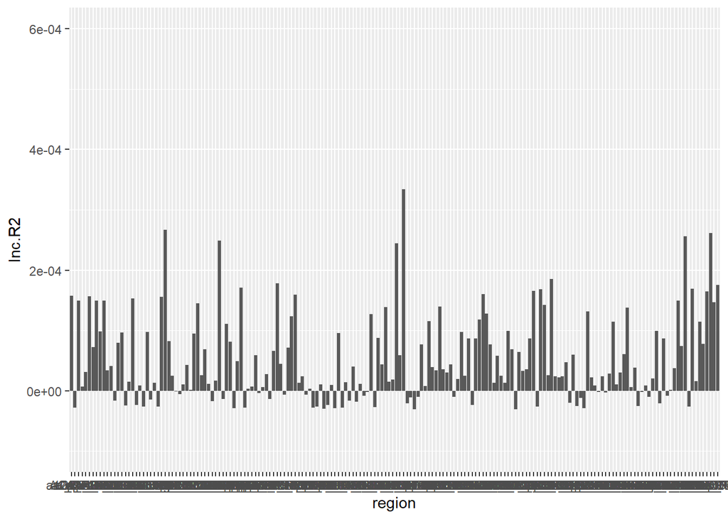

```r
vis.IncR2.CT <- ggplot(PGS.reg.pgs.CT_updated, aes(x=region, y=Inc.R2)) + geom_bar(stat="identity") + ylim(-0.0001, 0.0006)
vis.IncR2.CT
```

```r
summary(PGS.reg.pgs.MC_updated$Inc.R2)
```

```
##       Min.    1st Qu.     Median       Mean    3rd Qu.       Max.
## -3.118e-05 -2.656e-05 -1.472e-05  5.731e-06  1.018e-05  3.018e-04
```

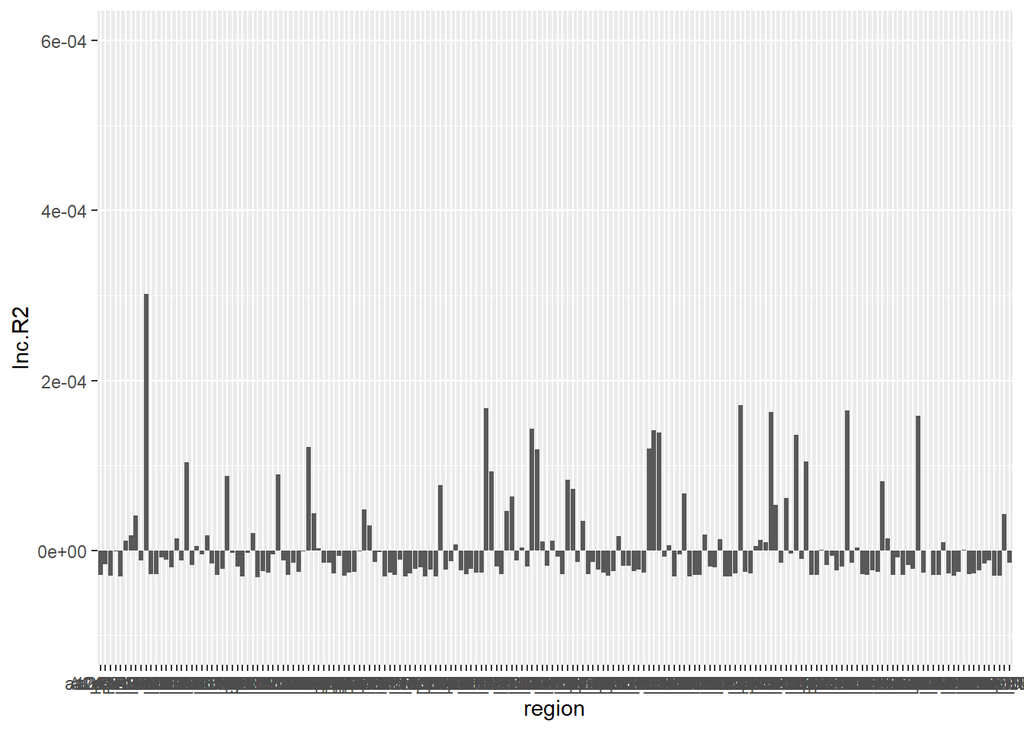

```r
vis.IncR2.MC <- ggplot(PGS.reg.pgs.MC_updated, aes(x=region, y=Inc.R2)) + geom_bar(stat="identity") + ylim(-0.0001, 0.0006)
vis.IncR2.MC
```

```r
summary(PGS.reg.pgs.ICVF_updated$Inc.R2)
```

```
##       Min.    1st Qu.     Median       Mean    3rd Qu.       Max.
## -3.103e-05 -9.509e-06  3.542e-05  5.803e-05  9.022e-05  5.928e-04
```

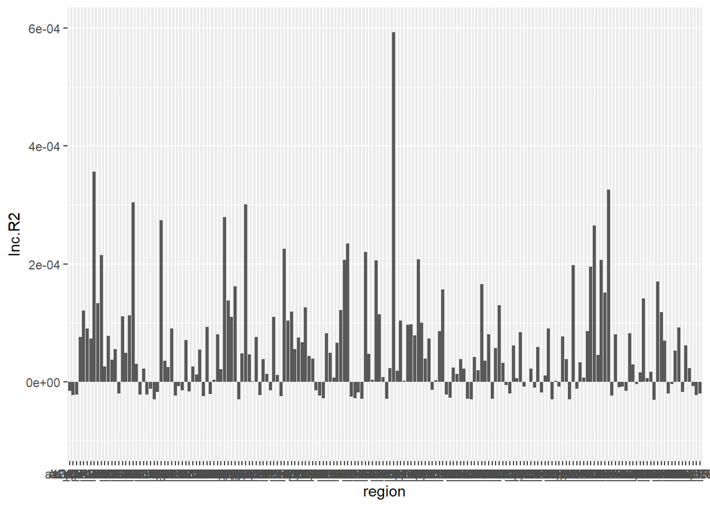

```r
vis.IncR2.ICVF <- ggplot(PGS.reg.pgs.ICVF_updated, aes(x=region, y=Inc.R2)) + geom_bar(stat="identity") + ylim(-0.0001, 0.0006)
vis.IncR2.ICVF
```

```r
# For Reg.IMG~PGS+Glb.IMG - Reg.IMG~Glb.IMG
PGS.reg.pgs.SA_updated_with_Glb.SA$Inc.R2 <- PGS.reg.pgs.SA_updated_with_Glb.SA$R2 - reg.pgs.SA_with_Glb.SA$R2
PGS.reg.pgs.CT_updated_with_Glb.CT$Inc.R2 <- PGS.reg.pgs.CT_updated_with_Glb.CT$R2 - reg.pgs.CT_with_Glb.CT$R2
PGS.reg.pgs.MC_updated_with_Glb.MC$Inc.R2 <- PGS.reg.pgs.MC_updated_with_Glb.MC$R2 - reg.pgs.MC_with_Glb.MC$R2
PGS.reg.pgs.ICVF_updated_with_Glb.ICVF$Inc.R2 <- PGS.reg.pgs.ICVF_updated_with_Glb.ICVF$R2 - reg.pgs.ICVF_with_Glb.ICVF$R2

summary(PGS.reg.pgs.SA_updated_with_Glb.SA$Inc.R2)
```

```
##       Min.    1st Qu.     Median       Mean    3rd Qu.       Max.
## -2.483e-05 -1.498e-05 -4.484e-06  5.327e-06  1.286e-05  1.321e-04
```

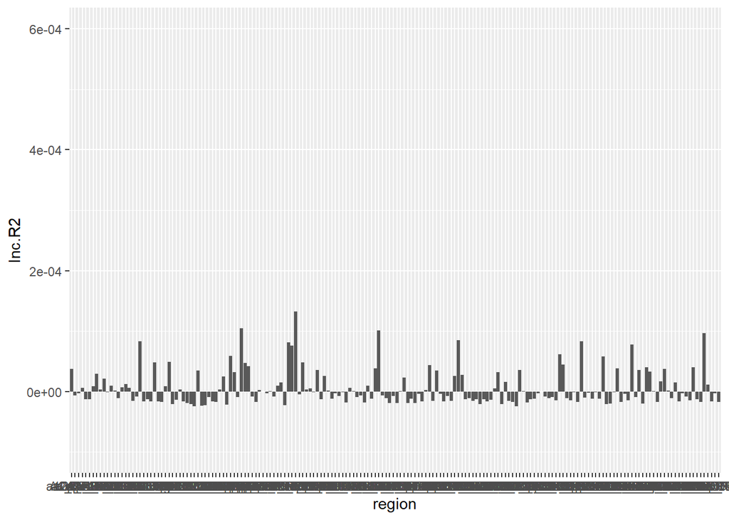

```r
vis.IncR2.SA.Glb <- ggplot(PGS.reg.pgs.SA_updated_with_Glb.SA, aes(x=region, y=Inc.R2)) + geom_bar(stat="identity") + ylim(-0.0001, 0.0006)
vis.IncR2.SA.Glb
```

```r
summary(PGS.reg.pgs.CT_updated_with_Glb.CT$Inc.R2)
```

```
##       Min.    1st Qu.     Median       Mean    3rd Qu.       Max.
## -2.835e-05 -1.808e-05 -1.160e-05  3.224e-08  4.156e-06  1.493e-04
```

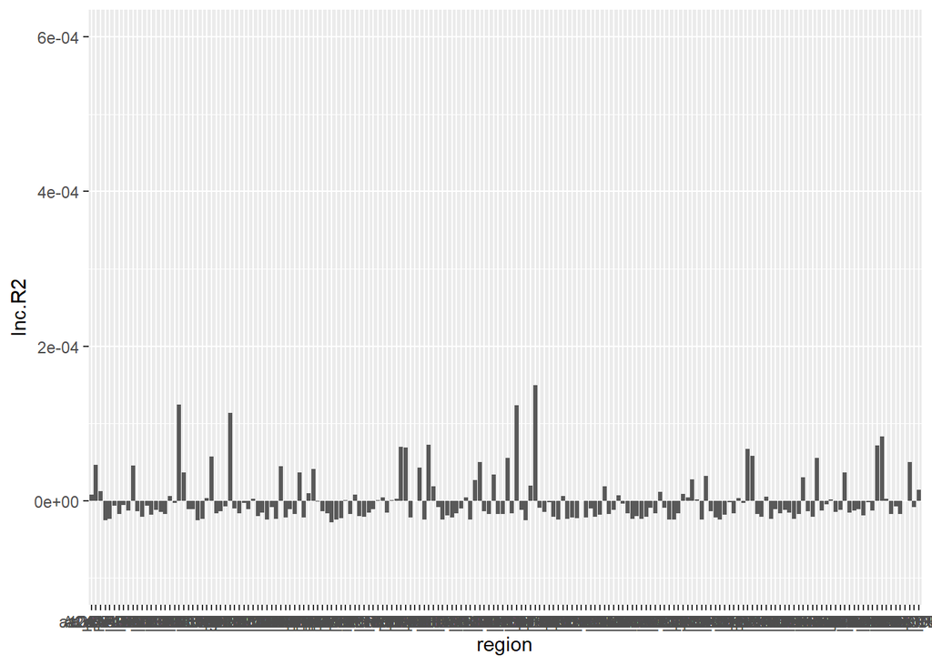

```r
vis.IncR2.CT.Glb <- ggplot(PGS.reg.pgs.CT_updated_with_Glb.CT, aes(x=region, y=Inc.R2)) + geom_bar(stat="identity") + ylim(-0.0001, 0.0006)
vis.IncR2.CT.Glb
```

```r
summary(PGS.reg.pgs.MC_updated_with_Glb.MC$Inc.R2)
```

```
##       Min.    1st Qu.     Median       Mean    3rd Qu.       Max.
## -3.013e-05 -2.401e-05 -1.632e-05  7.375e-06  1.013e-05  2.859e-04
```

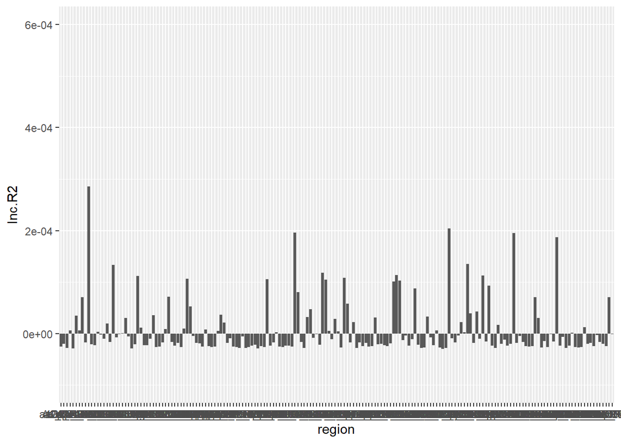

```r
vis.IncR2.MC.Glb <- ggplot(PGS.reg.pgs.MC_updated_with_Glb.MC, aes(x=region, y=Inc.R2)) + geom_bar(stat="identity") + ylim(-0.0001, 0.0006)
vis.IncR2.MC.Glb
```

```r
summary(PGS.reg.pgs.ICVF_updated_with_Glb.ICVF$Inc.R2)
```

```
##       Min.    1st Qu.     Median       Mean    3rd Qu.       Max.
## -2.678e-05 -1.432e-05 -7.022e-06  7.452e-06  1.633e-05  2.275e-04
```

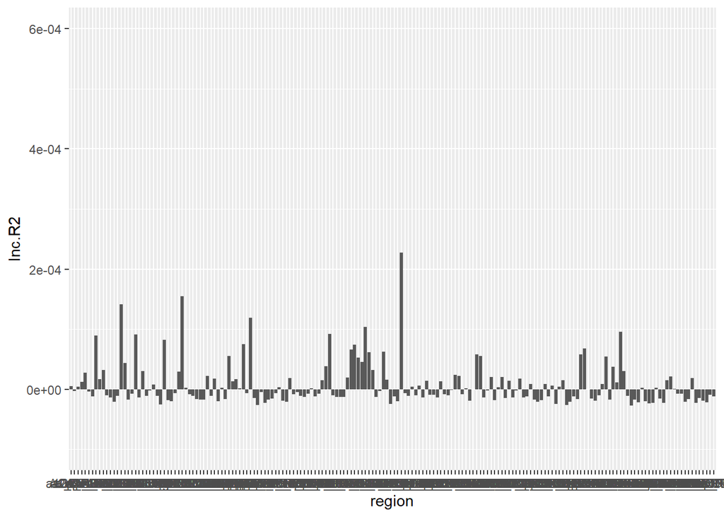

```r
vis.IncR2.ICVF.Glb <- ggplot(PGS.reg.pgs.ICVF_updated_with_Glb.ICVF, aes(x=region, y=Inc.R2)) + geom_bar(stat="identity") + ylim(-0.0001, 0.0006)
vis.IncR2.ICVF.Glb
```

```r
# For fReg.IMG~fPGS+fGlb.IMG - fReg.IMG~fGlb.IMG
f.reg.pgs.SA_updated_with_Glb.SA$Inc.R2 <- f.reg.pgs.SA_updated_with_Glb.SA$R2 - f.reg.pgs.SA_with_Glb.SA$R2
f.reg.pgs.CT_updated_with_Glb.CT$Inc.R2 <- f.reg.pgs.CT_updated_with_Glb.CT$R2 - f.reg.pgs.CT_with_Glb.CT$R2
f.reg.pgs.MC_updated_with_Glb.MC$Inc.R2 <- f.reg.pgs.MC_updated_with_Glb.MC$R2 - f.reg.pgs.MC_with_Glb.MC$R2
f.reg.pgs.ICVF_updated_with_Glb.ICVF$Inc.R2 <- f.reg.pgs.ICVF_updated_with_Glb.ICVF$R2 - f.reg.pgs.ICVF_with_Glb.ICVF$R2

summary(f.reg.pgs.SA_updated_with_Glb.SA$Inc.R2)
```

```
##       Min.    1st Qu.     Median       Mean    3rd Qu.       Max.
## -5.191e-05 -3.366e-05 -2.292e-05  3.519e-06  1.506e-05  2.682e-04
```

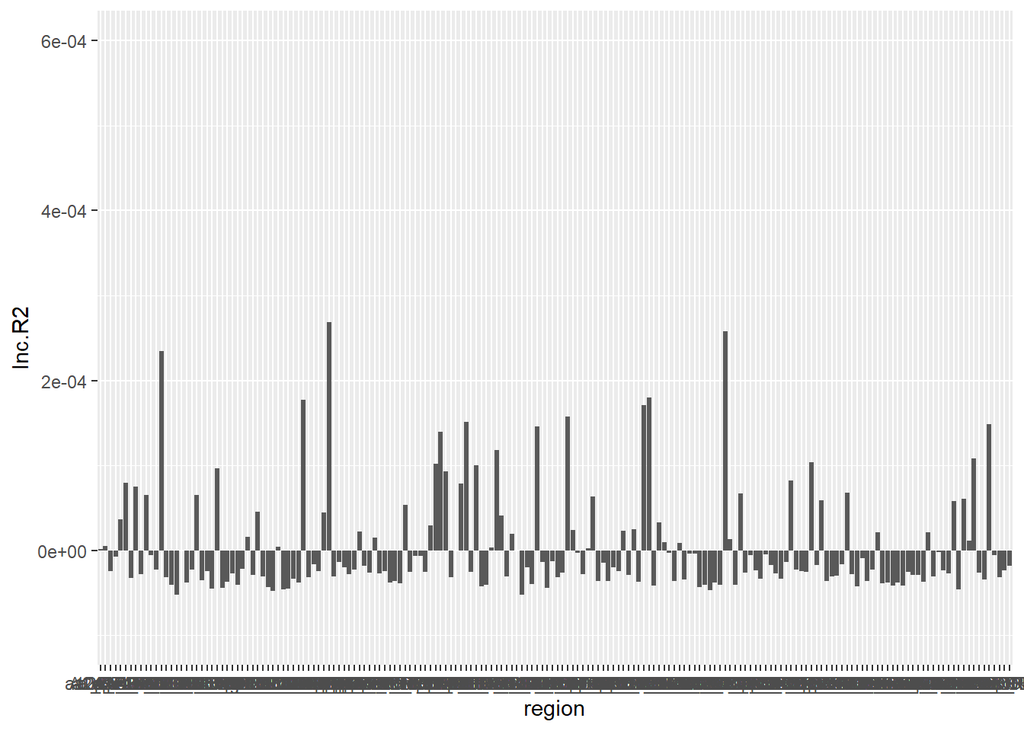

```r
f.vis.IncR2.SA.Glb <- ggplot(f.reg.pgs.SA_updated_with_Glb.SA, aes(x=region, y=Inc.R2)) + geom_bar(stat="identity") + ylim(-0.0001, 0.0006)
f.vis.IncR2.SA.Glb
```

```r
summary(f.reg.pgs.CT_updated_with_Glb.CT$Inc.R2)
```

```
##       Min.    1st Qu.     Median       Mean    3rd Qu.       Max.
## -5.405e-05 -3.587e-05 -1.708e-05  3.270e-06  9.354e-06  2.999e-04
```

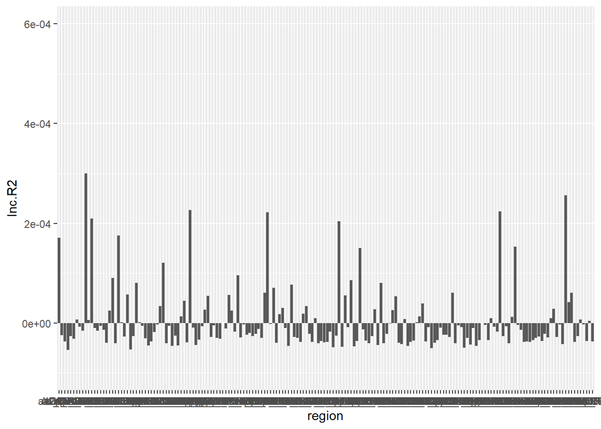

```r
f.vis.IncR2.CT.Glb <- ggplot(f.reg.pgs.CT_updated_with_Glb.CT, aes(x=region, y=Inc.R2)) + geom_bar(stat="identity") + ylim(-0.0001, 0.0006)
f.vis.IncR2.CT.Glb
```

```r
summary(f.reg.pgs.MC_updated_with_Glb.MC$Inc.R2)
```

```
##       Min.    1st Qu.     Median       Mean    3rd Qu.       Max.
## -5.426e-05 -4.215e-05 -2.137e-05  1.139e-05  3.423e-05  4.751e-04
```

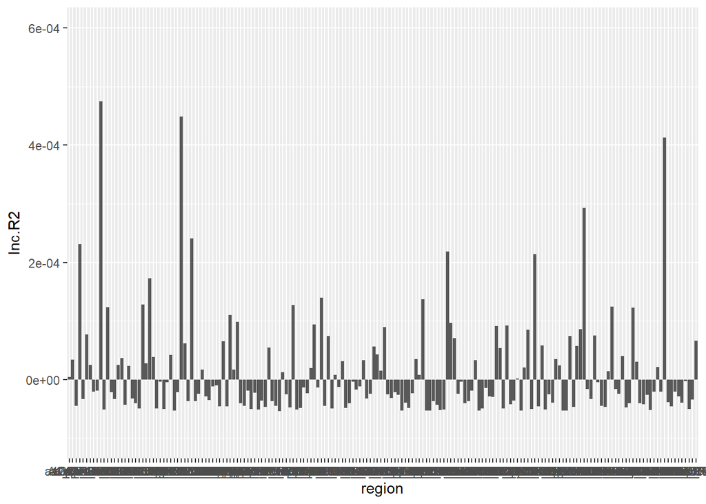

```r
f.vis.IncR2.MC.Glb <- ggplot(f.reg.pgs.MC_updated_with_Glb.MC, aes(x=region, y=Inc.R2)) + geom_bar(stat="identity") + ylim(-0.0001, 0.0006)
f.vis.IncR2.MC.Glb
```

```r
summary(f.reg.pgs.ICVF_updated_with_Glb.ICVF$Inc.R2)
```

```
##       Min.    1st Qu.     Median       Mean    3rd Qu.       Max.
## -5.110e-05 -2.798e-05 -1.751e-05 -5.645e-06  5.634e-06  1.382e-04
```

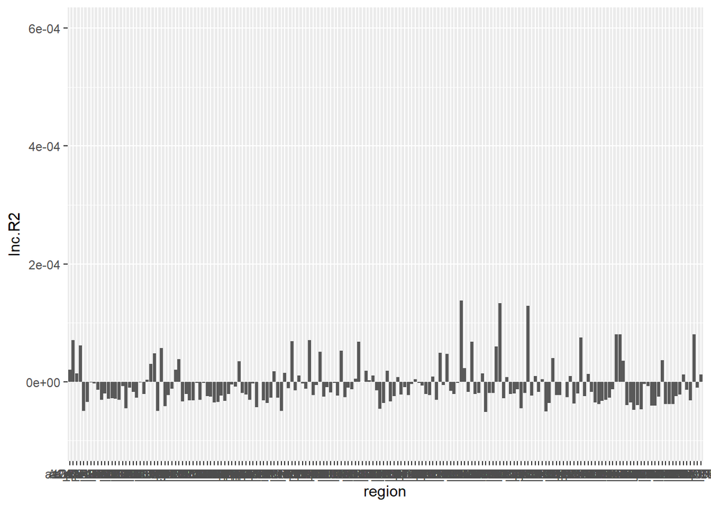

```r
f.vis.IncR2.ICVF.Glb <- ggplot(f.reg.pgs.ICVF_updated_with_Glb.ICVF, aes(x=region, y=Inc.R2)) + geom_bar(stat="identity") + ylim(-0.0001, 0.0006)
f.vis.IncR2.ICVF.Glb
```

```r
# For mReg.IMG~mPGS+mGlb.IMG
m.reg.pgs.SA_updated_with_Glb.SA$Inc.R2 <- m.reg.pgs.SA_updated_with_Glb.SA$R2 - m.reg.pgs.SA_with_Glb.SA$R2
m.reg.pgs.CT_updated_with_Glb.CT$Inc.R2 <- m.reg.pgs.CT_updated_with_Glb.CT$R2 - m.reg.pgs.CT_with_Glb.CT$R2
m.reg.pgs.MC_updated_with_Glb.MC$Inc.R2 <- m.reg.pgs.MC_updated_with_Glb.MC$R2 - m.reg.pgs.MC_with_Glb.MC$R2
m.reg.pgs.ICVF_updated_with_Glb.ICVF$Inc.R2 <- m.reg.pgs.ICVF_updated_with_Glb.ICVF$R2 - m.reg.pgs.ICVF_with_Glb.ICVF$R2

summary(m.reg.pgs.SA_updated_with_Glb.SA$Inc.R2)
```

```
##       Min.    1st Qu.     Median       Mean    3rd Qu.       Max.
## -5.722e-05 -3.738e-05 -2.004e-05  7.316e-07  2.314e-05  2.959e-04
```

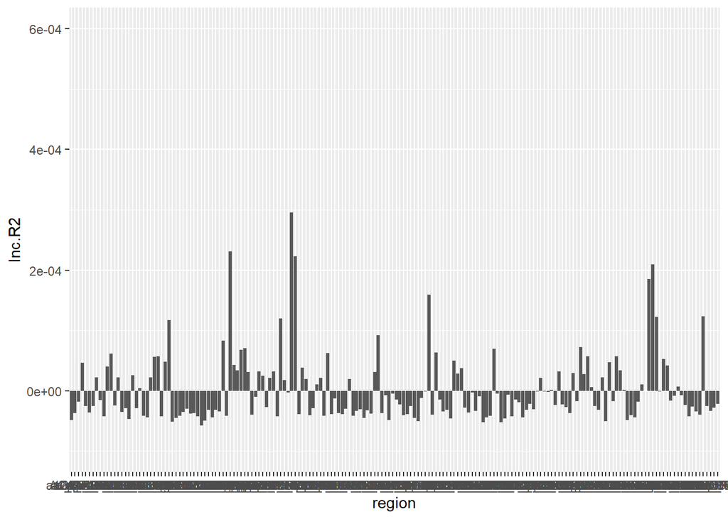

```r
m.vis.IncR2.SA.Glb <- ggplot(m.reg.pgs.SA_updated_with_Glb.SA, aes(x=region, y=Inc.R2)) + geom_bar(stat="identity") + ylim(-0.0001, 0.0006)
m.vis.IncR2.SA.Glb
```

```r
summary(m.reg.pgs.CT_updated_with_Glb.CT$Inc.R2)
```

```
##       Min.    1st Qu.     Median       Mean    3rd Qu.       Max.
## -5.767e-05 -4.060e-05 -2.424e-05  2.167e-06  1.614e-05  4.928e-04
```

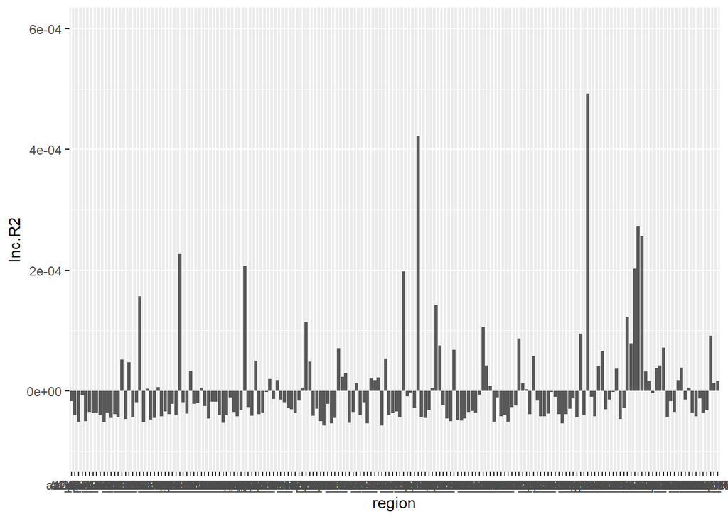

```r
m.vis.IncR2.CT.Glb <- ggplot(m.reg.pgs.CT_updated_with_Glb.CT, aes(x=region, y=Inc.R2)) + geom_bar(stat="identity") + ylim(-0.0001, 0.0006)
m.vis.IncR2.CT.Glb
```

```r
summary(m.reg.pgs.MC_updated_with_Glb.MC$Inc.R2)
```

```
##       Min.    1st Qu.     Median       Mean    3rd Qu.       Max.
## -6.510e-05 -4.966e-05 -3.514e-05 -6.434e-06  1.503e-05  3.082e-04
```

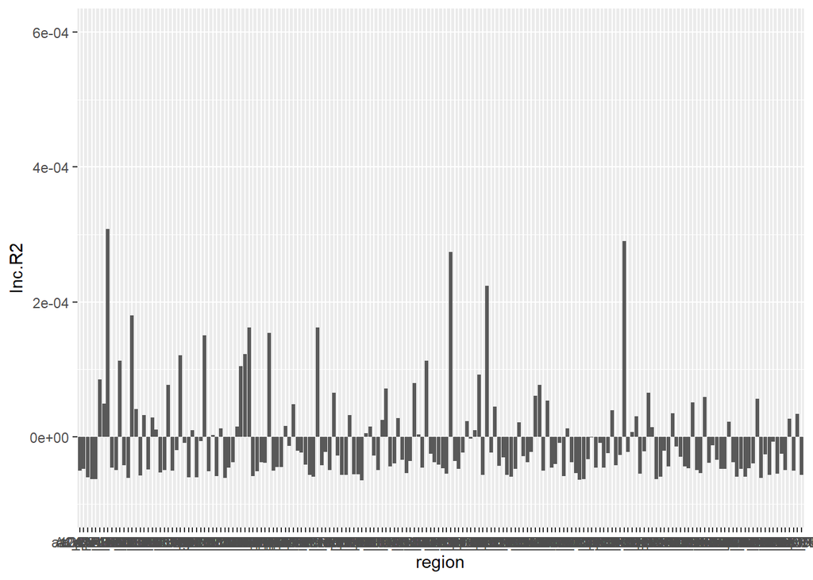

```r
m.vis.IncR2.MC.Glb <- ggplot(m.reg.pgs.MC_updated_with_Glb.MC, aes(x=region, y=Inc.R2)) + geom_bar(stat="identity") + ylim(-0.0001, 0.0006)
m.vis.IncR2.MC.Glb
```

```r
summary(m.reg.pgs.ICVF_updated_with_Glb.ICVF$Inc.R2)
```

```
##       Min.    1st Qu.     Median       Mean    3rd Qu.       Max.
## -5.952e-05 -3.218e-05 -1.915e-05  1.174e-06  1.323e-05  2.908e-04
```

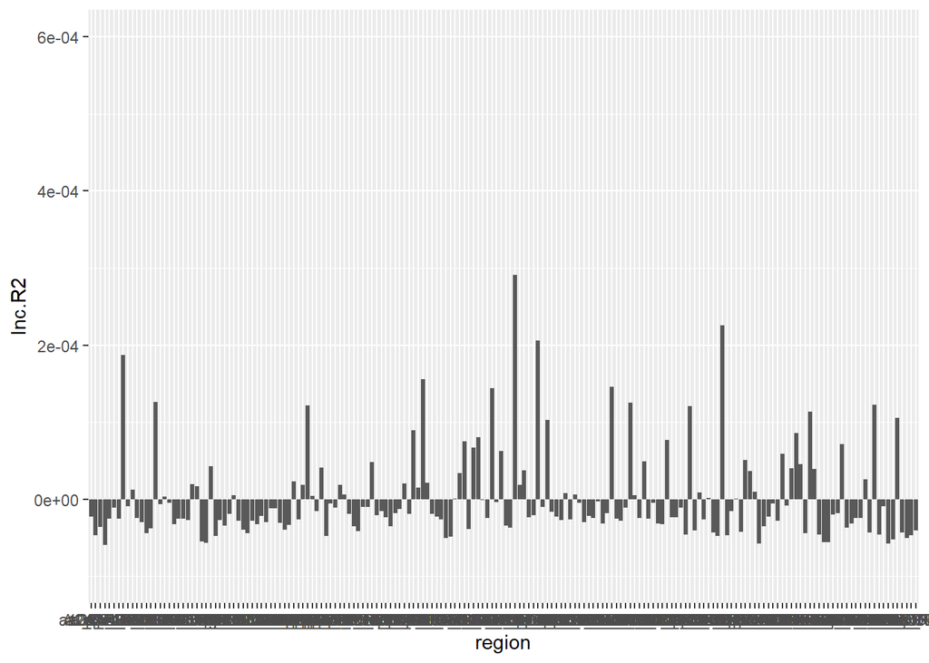

```r
m.vis.IncR2.ICVF.Glb <- ggplot(m.reg.pgs.ICVF_updated_with_Glb.ICVF, aes(x=region, y=Inc.R2)) + geom_bar(stat="identity") + ylim(-0.0001, 0.0006)
m.vis.IncR2.ICVF.Glb
```

```r
# For PGS:SEX in Reg.IMG~PGS:SEX
PGS.reg.pgs.SA_updated_with_Glb.SA_SEX$Inc.R2.SEX <- PGS.reg.pgs.SA_updated_with_Glb.SA_SEX$R2 - PGS.reg.pgs.SA_updated_with_Glb.SA$R2
PGS.reg.pgs.CT_updated_with_Glb.CT_SEX$Inc.R2.SEX <- PGS.reg.pgs.CT_updated_with_Glb.CT_SEX$R2 - PGS.reg.pgs.CT_updated_with_Glb.CT$R2
PGS.reg.pgs.MC_updated_with_Glb.MC_SEX$Inc.R2.SEX <- PGS.reg.pgs.MC_updated_with_Glb.MC_SEX$R2 - PGS.reg.pgs.MC_updated_with_Glb.MC$R2
PGS.reg.pgs.ICVF_updated_with_Glb.ICVF_SEX$Inc.R2.SEX <- PGS.reg.pgs.ICVF_updated_with_Glb.ICVF_SEX$R2 - PGS.reg.pgs.ICVF_updated_with_Glb.ICVF$R2

summary(PGS.reg.pgs.SA_updated_with_Glb.SA_SEX$Inc.R2.SEX)
```

```
##       Min.    1st Qu.     Median       Mean    3rd Qu.       Max.
## -2.499e-05 -1.505e-05 -9.050e-06  6.815e-08  5.734e-06  1.371e-04
```

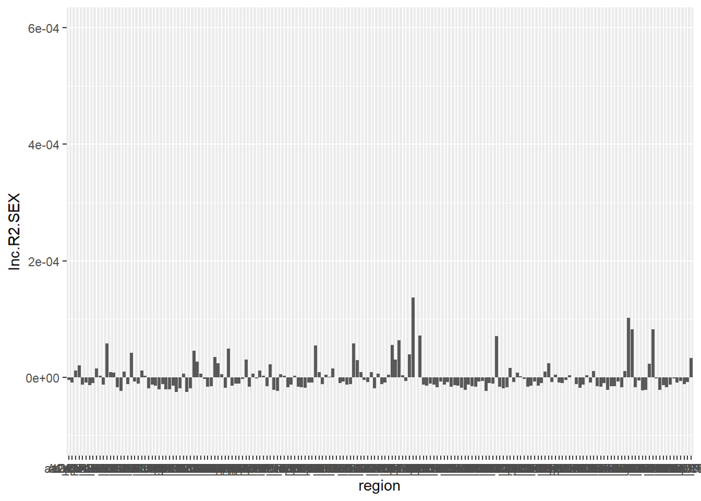

```r
vis.IncR2.SA.Glb.SEXPGS <- ggplot(PGS.reg.pgs.SA_updated_with_Glb.SA_SEX, aes(x=region, y=Inc.R2.SEX)) + geom_bar(stat="identity") + ylim(-0.0001, 0.0006)
vis.IncR2.SA.Glb.SEXPGS
```

```r
summary(PGS.reg.pgs.CT_updated_with_Glb.CT_SEX$Inc.R2.SEX)
```

```
##       Min.    1st Qu.     Median       Mean    3rd Qu.       Max.
## -2.734e-05 -1.859e-05 -1.059e-05 -8.355e-07  8.498e-06  1.245e-04
```

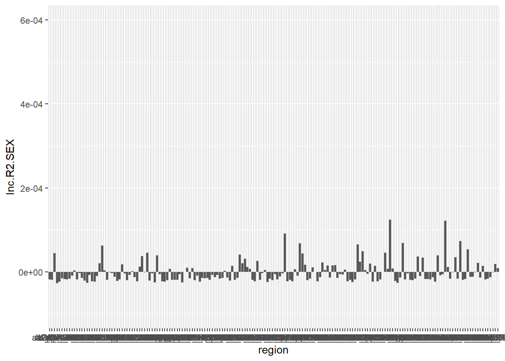

```r
vis.IncR2.CT.Glb.SEXPGS <- ggplot(PGS.reg.pgs.CT_updated_with_Glb.CT_SEX, aes(x=region, y=Inc.R2.SEX)) + geom_bar(stat="identity") + ylim(-0.0001, 0.0006)
vis.IncR2.CT.Glb.SEXPGS
```